# National analysis (puma-level)

Author

Natalie Novoseltseva

# 1 About this qmd

This qmd includes the national analysis: all 2,462 PUMAs in the 50 states and DC.

It reads two saved files and joins them:

- `data/final/national_puma_dataset_2022_2024.gpkg` from `processing_national_pumas_2022_2024.qmd`: outcomes, controls and PUMA boundaries
- `data/final/puma_prison_exposure.csv` from `processing_prison_exposure.qmd`: the prison exposure measures

Outcomes:

- `overdose_rate_2022_2024`: overdose deaths per 100,000, pooled 2022–2024 (CDC tract data)
- `pct_divorced_past_yr`: % of ever-married people who divorced in the past year, pooled 2022–2024 ACS

Sections:

1. Descriptives: summary statistics, maps, correlations and unadjusted group comparisons
2. Staged OLS models (M1 to M3), SEs clustered by state
3. Spatial diagnostics: Moran’s I on the outcomes and on the M3 residuals
4. Spatial models: SEM and SDEM, model checks 5

# 2 Setup

```r
library(tidyverse)
library(sf)
library(gt)
library(broom)
library(fixest)
library(spdep)
library(spatialreg)
library(tigris)
library(patchwork)

options(tigris_use_cache = TRUE)
set.seed(2024)
```

## 2.1 Data

```r
# Exposure measures from processing_prison_exposure.qmd, outcomes and controls (with boundaries)
# from processing_national_pumas_2022_2024.qmd
exposure <- read_csv("data/final/puma_prison_exposure.csv",
                     col_types = cols(GEOID20 = col_character()))

puma_geo <- st_read("data/final/national_puma_dataset_2022_2024.gpkg", quiet = TRUE) %>%
  select(-any_of(setdiff(names(exposure), "GEOID20"))) %>%   # avoid .x/.y if the gpkg already has exposure columns
  left_join(exposure, by = "GEOID20")

puma_df <- puma_geo %>% st_drop_geometry()

nrow(puma_df)   # 2462
```

```
[1] 2462
```

```r
# Outcomes and their labels, used throughout
outcomes <- c(
  overdose_rate_2022_2024 = "Overdose deaths per 100,000",
  pct_divorced_past_yr    = "% of ever-married divorced in past year"
)

# Lower 48 for maps (Alaska and Hawaii would stretch the map); projected for correct shapes
puma_geo_l48 <- puma_geo %>%
  filter(!state_fips %in% c("02", "15")) %>%
  st_transform(5070)

# Open state and federal prisons, for plotting on the maps
prisons <- st_read("data/raw/prison-boundaries-1-geojson.geojson", quiet = TRUE) %>%
  st_make_valid() %>%
  filter(STATUS == "OPEN", TYPE %in% c("STATE", "FEDERAL")) %>%
  st_centroid() %>%
  st_transform(5070) %>%
  st_filter(st_union(puma_geo_l48))
```

# 3 DESCRIPTIVES

## 3.1 Summary statistics

```r
summary_vars <- c(names(outcomes),
                  "prison_exp_h1", "prison_exp_h5", "prison_exp_h10", "prison_exp_h25",
                   "num_prisons_in_puma",
                  "pop_density", "pct_pop_rural", "pct_pop_nonmetro")

puma_df %>%
  select(all_of(summary_vars)) %>%
  pivot_longer(everything(), names_to = "variable") %>%
  group_by(variable) %>%
  summarise(n = sum(!is.na(value)),
            mean = mean(value, na.rm = TRUE), sd = sd(value, na.rm = TRUE),
            min = min(value, na.rm = TRUE), median = median(value, na.rm = TRUE),
            max = max(value, na.rm = TRUE)) %>%
  mutate(variable = factor(variable, levels = summary_vars)) %>%
  arrange(variable) %>%
  gt() %>%
  fmt_number(columns = c(mean, sd, min, median, max), decimals = 2) %>%
  tab_header(title = "Summary statistics, PUMAs (2022–2024)")
```

Summary statistics, PUMAs (2022–2024)

| variable | n | mean | sd | min | median | max |
| --- | --- | --- | --- | --- | --- | --- |
| overdose_rate_2022_2024 | 2462 | 27.51 | 18.13 | 0.47 | 22.99 | 152.09 |
| pct_divorced_past_yr | 2462 | 1.06 | 0.43 | 0.05 | 1.00 | 3.39 |
| prison_exp_h1 | 2462 | 0.02 | 0.05 | 0.00 | 0.00 | 1.17 |
| prison_exp_h5 | 2462 | 0.27 | 0.45 | 0.00 | 0.11 | 6.59 |
| prison_exp_h10 | 2462 | 0.79 | 0.92 | 0.00 | 0.48 | 9.85 |
| prison_exp_h25 | 2462 | 3.04 | 2.31 | 0.00 | 2.43 | 15.82 |
| num_prisons_in_puma | 2462 | 0.80 | 1.59 | 0.00 | 0.00 | 21.00 |
| pop_density | 2462 | 1,271.94 | 3,020.20 | 0.10 | 435.92 | 40,432.44 |
| pct_pop_rural | 2462 | 5.78 | 12.79 | 0.00 | 0.00 | 86.85 |
| pct_pop_nonmetro | 2462 | 16.73 | 31.46 | 0.00 | 0.00 | 100.00 |

```r
table(puma_df$prison_present_in_puma, useNA = "ifany")   # PUMAs with / without a prison inside
```

```
   0    1
1593  869
```

## 3.2 Maps

```r
# Census region outlines: state boundaries dissolved by region
region_map <- tigris::states(cb = TRUE, year = 2020, progress_bar = FALSE) %>%
  filter(STATEFP %in% unique(puma_geo_l48$state_fips)) %>%
  left_join(
    tibble(STUSPS = c(state.abb, "DC"),
           region = c(as.character(state.region), "South")) %>%
      mutate(region = recode(region, "North Central" = "Midwest")),
    by = "STUSPS"
  ) %>%
  st_transform(st_crs(puma_geo_l48)) %>%
  group_by(region) %>%
  summarise()

# Pieces shared by the maps; add them with "+"
map_theme    <- list(theme_void(), theme(plot.title = element_text(face = "bold")))
region_layer <- geom_sf(data = region_map, fill = NA, colour = "black", linewidth = 0.4)
prison_layer <- geom_sf(data = prisons, size = 0.5, colour = "deepskyblue3", alpha = 0.7)
```

### 3.2.1 Outcomes (add maps by years)

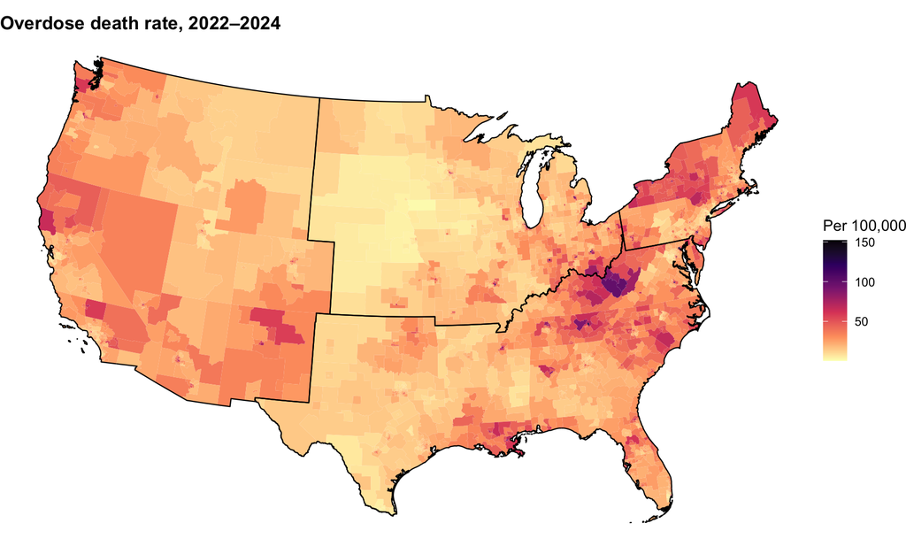

```r
ggplot(puma_geo_l48) +
  geom_sf(aes(fill = overdose_rate_2022_2024), colour = NA) +
  scale_fill_viridis_c(name = "Per 100,000", option = "magma", direction = -1,
                       na.value = "grey85") +
  region_layer +
  labs(title = "Overdose death rate, 2022–2024") +
  map_theme
```

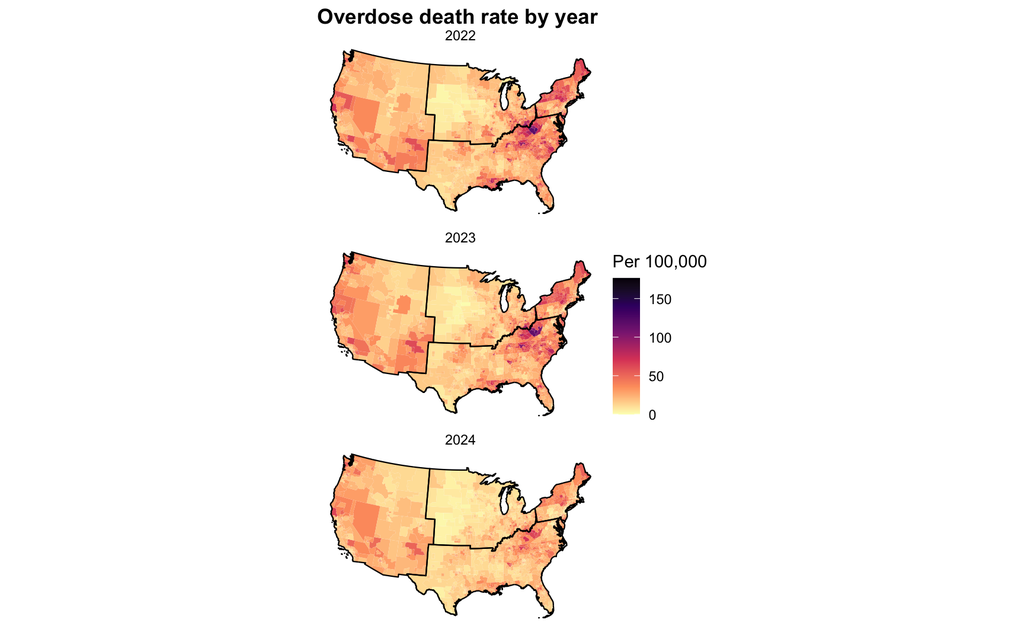

```r
# One map per year, same colour scale so the years can be compared
puma_geo_l48 %>%
  select(GEOID20, overdose_rate_2022, overdose_rate_2023, overdose_rate_2024) %>%
  pivot_longer(starts_with("overdose_rate_"), names_to = "year", values_to = "rate",
               names_prefix = "overdose_rate_") %>%
  ggplot() +
  geom_sf(aes(fill = rate), colour = NA) +
  scale_fill_viridis_c(name = "Per 100,000", option = "magma", direction = -1,
                       na.value = "grey85") +
  region_layer +
  facet_wrap(~ year, ncol = 1) +
  labs(title = "Overdose death rate by year") +
  map_theme
```

When we look at the overdose rates for each year separately, we see that 2024 has much lower rates across the whole country (a drop of about 24%). A quick google search confirms this and attributes it to new state policies and access to naloxone (narcan). This makes me wonder whether pooling all these years into one dataset is still okay, and whether I should find a way to also control for access to naloxone or for drug/healthcare policies at the state level(or state fixed effects are enough)?

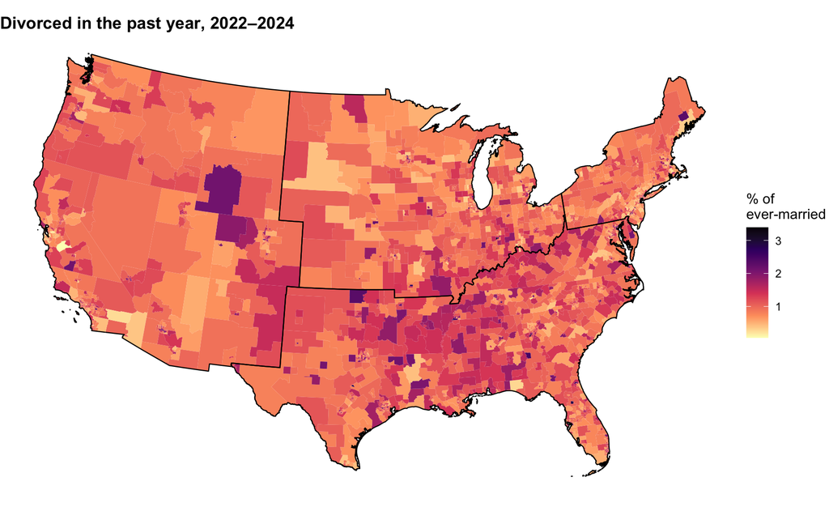

```r
ggplot(puma_geo_l48) +
  geom_sf(aes(fill = pct_divorced_past_yr), colour = NA) +
  scale_fill_viridis_c(name = "% of\never-married", option = "magma", direction = -1,
                       na.value = "grey85") +
  region_layer +
  labs(title = "Divorced in the past year, 2022–2024") +
  map_theme
```

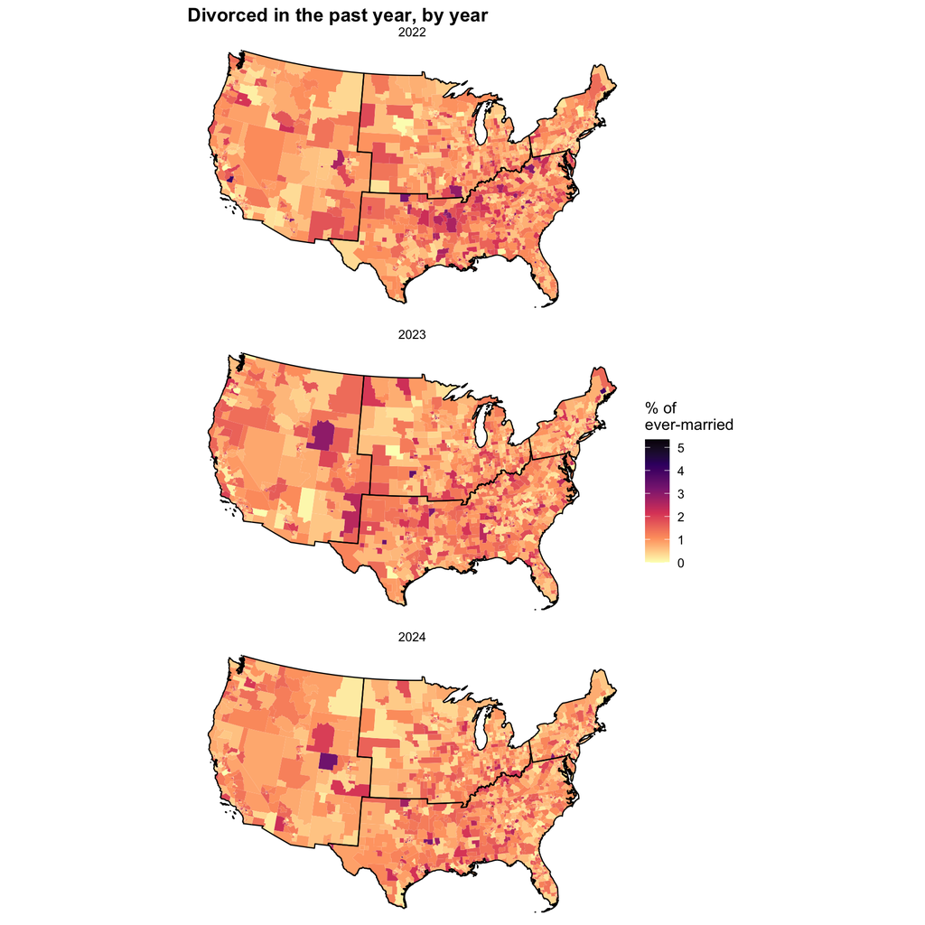

```r
# One map per year, same colour scale so the years can be compared
puma_geo_l48 %>%
  select(GEOID20, pct_divorced_past_yr_2022, pct_divorced_past_yr_2023, pct_divorced_past_yr_2024) %>%
  pivot_longer(starts_with("pct_divorced_past_yr_20"), names_to = "year", values_to = "rate",
               names_prefix = "pct_divorced_past_yr_") %>%
  ggplot() +
  geom_sf(aes(fill = rate), colour = NA) +
  scale_fill_viridis_c(name = "% of\never-married", option = "magma", direction = -1,
                       na.value = "grey85") +
  region_layer +
  facet_wrap(~ year, ncol = 1) +
  labs(title = "Divorced in the past year, by year") +
  map_theme
```

The divorce rates seem more stable across the years.

### 3.2.2 Prisons and exposure

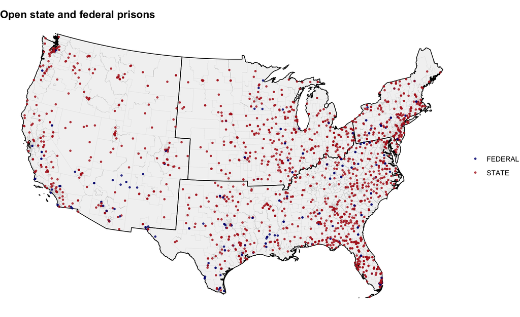

```r
# where the prisons are (open state and federal facilities)
ggplot() +
  geom_sf(data = puma_geo_l48, fill = "grey95", colour = "grey80", linewidth = 0.05) +
  region_layer +
  geom_sf(data = prisons, aes(colour = TYPE), size = 0.7, alpha = 0.8) +
  scale_colour_manual(values = c(STATE = "firebrick", FEDERAL = "navy"), name = NULL) +
  labs(title = "Open state and federal prisons") +
  map_theme
```

Exposure at the four decay scales (h=1, h=5, h=10, h=25)

I am still conflicted about which of these four should be “the main measure”… I know for sure that it is not going to be 25 km, because that is too far and does not really make sense. Conceptually, h = 1 and h = 5 make the most sense to me, but because few such places exist, I am wondering whether it makes sense to use them. Also, when running the models, we can see that the effect and its significance fade/weaken as h increases, so maybe I actually need all of them…?

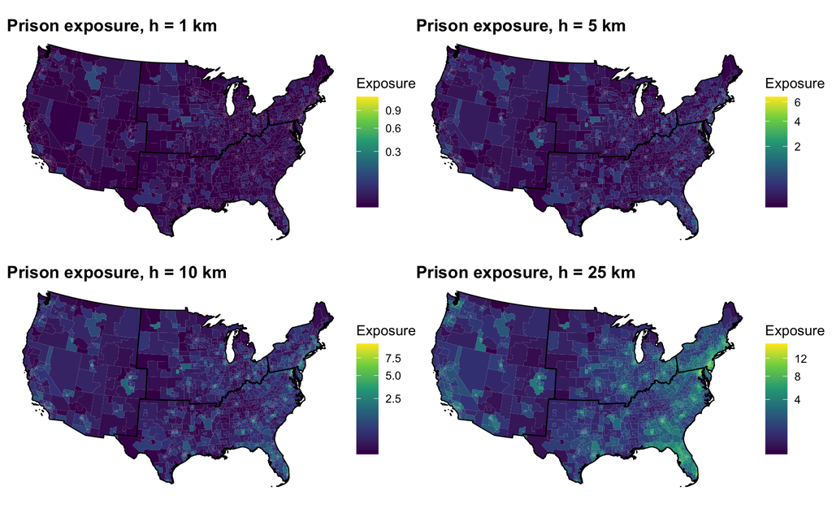

```r
exp_h1 <- ggplot(puma_geo_l48) +
  geom_sf(aes(fill = prison_exp_h1), colour = NA) +
  scale_fill_viridis_c(name = "Exposure", option = "viridis", trans = "sqrt",
                       na.value = "grey85") +
  region_layer +
  labs(title = "Prison exposure, h = 1 km") +
  map_theme

exp_h5 <- ggplot(puma_geo_l48) +
  geom_sf(aes(fill = prison_exp_h5), colour = NA) +
  scale_fill_viridis_c(name = "Exposure", option = "viridis", trans = "sqrt",
                       na.value = "grey85") +
  region_layer +
  labs(title = "Prison exposure, h = 5 km") +
  map_theme

exp_h10 <- ggplot(puma_geo_l48) +
  geom_sf(aes(fill = prison_exp_h10), colour = NA) +
  scale_fill_viridis_c(name = "Exposure", option = "viridis", trans = "sqrt",
                       na.value = "grey85") +
  region_layer +
  labs(title = "Prison exposure, h = 10 km") +
  map_theme

exp_h25 <- ggplot(puma_geo_l48) +
  geom_sf(aes(fill = prison_exp_h25), colour = NA) +
  scale_fill_viridis_c(name = "Exposure", option = "viridis", trans = "sqrt",
                       na.value = "grey85") +
  region_layer +
  labs(title = "Prison exposure, h = 25 km") +
  map_theme

(exp_h1 + exp_h5) / (exp_h10 + exp_h25)
```

Count-based exposure measures:

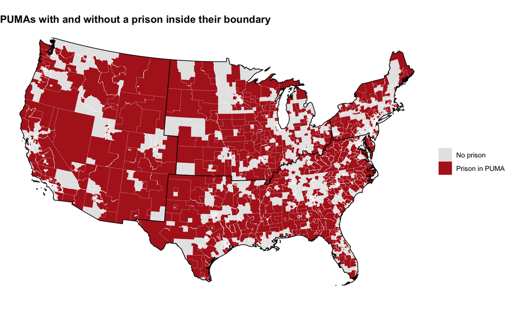

```r
# PUMAs with at least one open state or federal prison inside their boundary
puma_geo_l48 %>%
  mutate(presence = if_else(prison_present_in_puma == 1, "Prison in PUMA", "No prison")) %>%
  ggplot() +
  geom_sf(aes(fill = presence), colour = "white", linewidth = 0.05) +
  scale_fill_manual(values = c("Prison in PUMA" = "firebrick", "No prison" = "grey90"),
                    name = NULL, na.value = "grey85") +
  region_layer +
  labs(title = "PUMAs with and without a prison inside their boundary") +
  map_theme
```

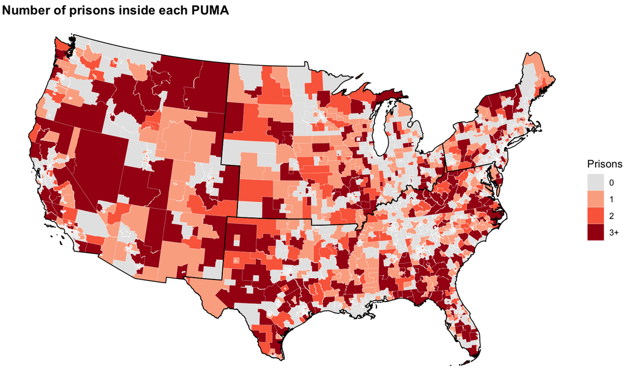

```r
# Number of open state and federal prisons inside each PUMA
puma_geo_l48 %>%
  mutate(n_prisons = cut(num_prisons_in_puma, breaks = c(-Inf, 0, 1, 2, Inf),
                         labels = c("0", "1", "2", "3+"))) %>%
  ggplot() +
  geom_sf(aes(fill = n_prisons), colour = "white", linewidth = 0.05) +
  scale_fill_manual(values = c("0" = "grey90", "1" = "#fcae91", "2" = "#fb6a4a", "3+" = "#a50f15"),
                    name = "Prisons", na.value = "grey85") +
  region_layer +
  labs(title = "Number of prisons inside each PUMA") +
  map_theme
```

From the maps and the test below, it is evident that these two are actually not that different. So I think I should either choose the number of prisons, since it is the more informative measure, or just discuss them as a pair of count-based measures, basically in contrast to the distance-decay group.

### 3.2.3 Settlement geography

These are the variables that go into M2 (the model specification, which includes area/population characteristics).

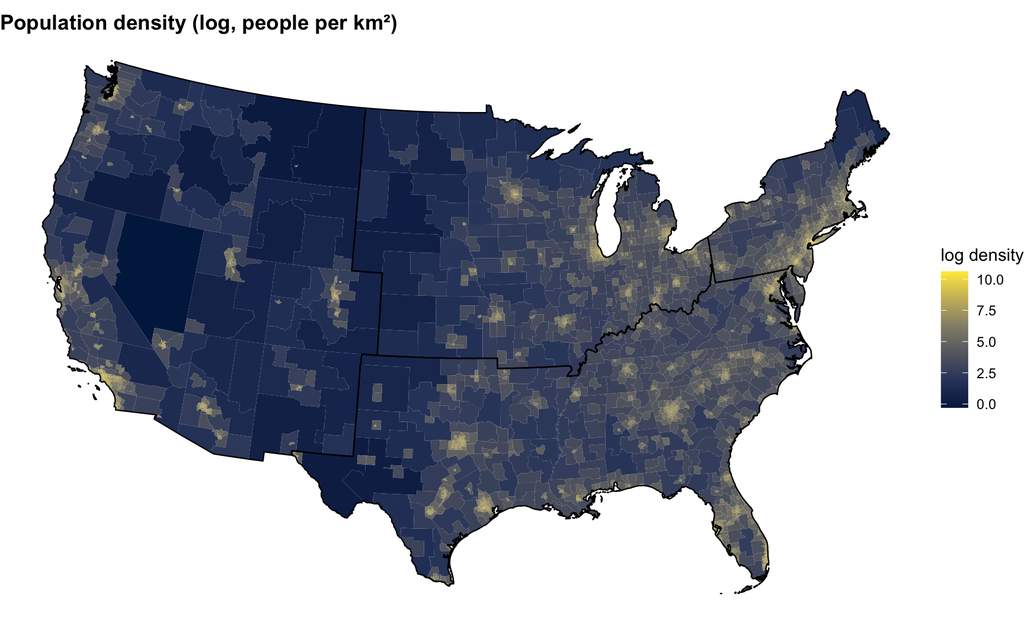

```r
ggplot(puma_geo_l48) +
  geom_sf(aes(fill = log_pop_density), colour = NA) +
  scale_fill_viridis_c(name = "log density", option = "cividis", na.value = "grey85") +
  region_layer +
  labs(title = "Population density (log, people per km²)") +
  map_theme
```

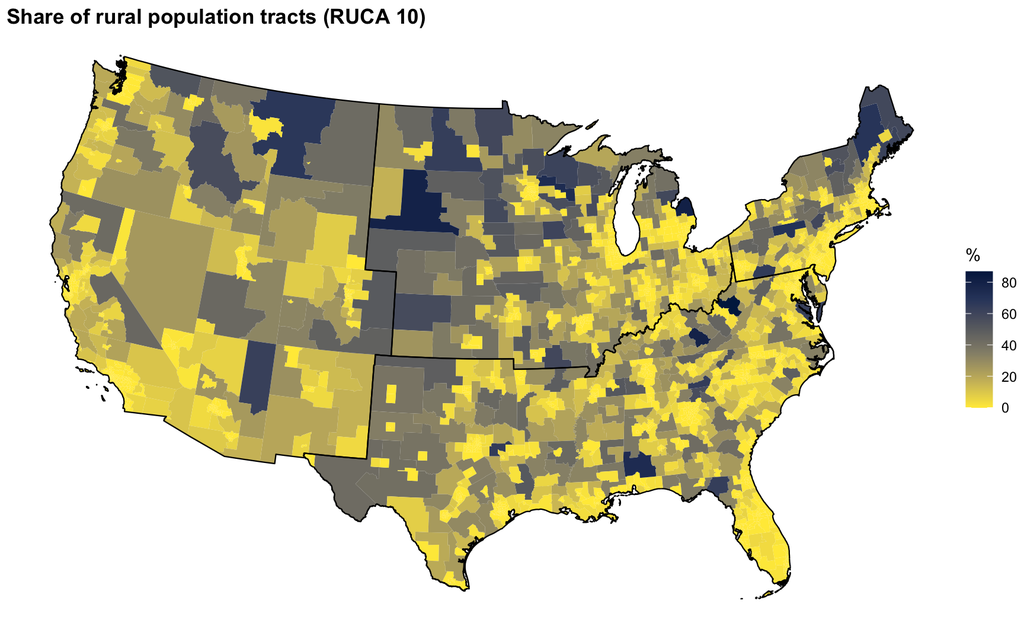

```r
ggplot(puma_geo_l48) +
  geom_sf(aes(fill = pct_pop_rural), colour = NA) +
  scale_fill_viridis_c(name = "%", option = "cividis", direction = -1, na.value = "grey85") +
  region_layer +
  labs(title = "Share of rural population tracts (RUCA 10)") +
  map_theme
```

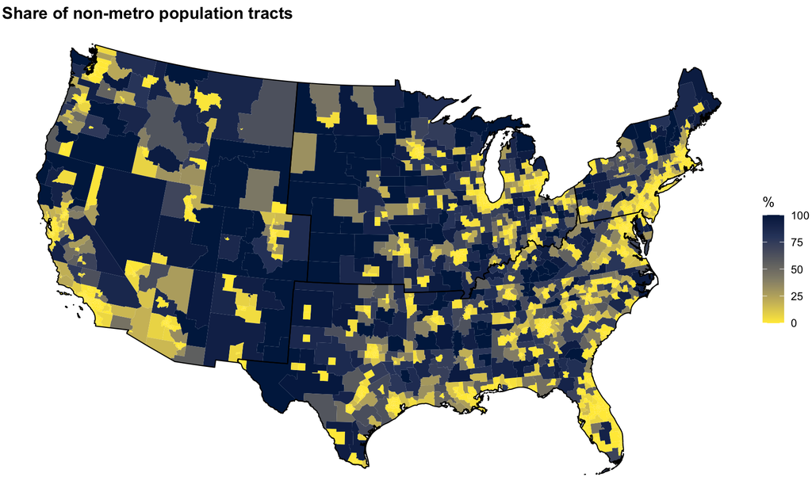

```r
ggplot(puma_geo_l48) +
  geom_sf(aes(fill = pct_pop_nonmetro), colour = NA) +
  scale_fill_viridis_c(name = "%", option = "cividis", direction = -1, na.value = "grey85") +
  region_layer +
  labs(title = "Share of non-metro population tracts") +
  map_theme
```

### 3.2.4 Which PUMAs are selected as rural and as non-metro

A PUMA is selected when more than half of its population lives in that type of tract.

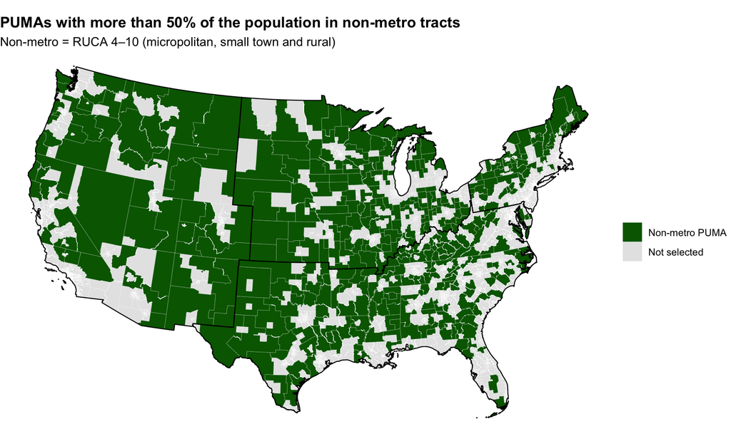

```r
puma_geo_l48 %>%
  mutate(selected = if_else(pct_pop_nonmetro > 50, "Non-metro PUMA", "Not selected")) %>%
  ggplot() +
  geom_sf(aes(fill = selected), colour = "white", linewidth = 0.05) +
  scale_fill_manual(values = c("Non-metro PUMA" = "darkgreen", "Not selected" = "grey90"),
                    name = NULL, na.value = "grey85") +
  region_layer +
  labs(title = "PUMAs with more than 50% of the population in non-metro tracts",
       subtitle = "Non-metro = RUCA 4–10 (micropolitan, small town and rural)") +
  map_theme
```

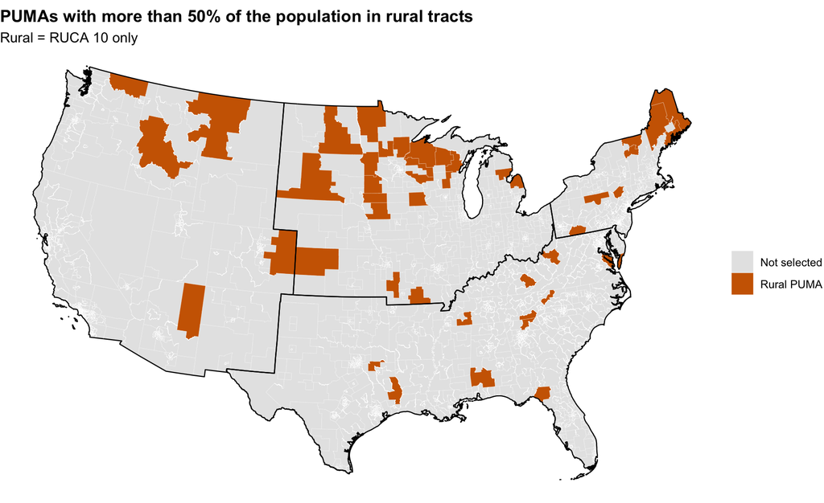

```r
puma_geo_l48 %>%
  mutate(selected = if_else(pct_pop_rural > 50, "Rural PUMA", "Not selected")) %>%
  ggplot() +
  geom_sf(aes(fill = selected), colour = "white", linewidth = 0.05) +
  scale_fill_manual(values = c("Rural PUMA" = "darkorange3", "Not selected" = "grey90"),
                    name = NULL, na.value = "grey85") +
  region_layer +
  labs(title = "PUMAs with more than 50% of the population in rural tracts",
       subtitle = "Rural = RUCA 10 only") +
  map_theme
```

Based on this definition, we end up with too few fully rural pumas, so I think it makes sense to proceed with the non-metro PUMAs and use the variable pct_pop_nonmetro both in the models and for filtering the rural subset.

## 3.3 Correlations

Spearman correlations, since most of the exposure measures are very skewed.

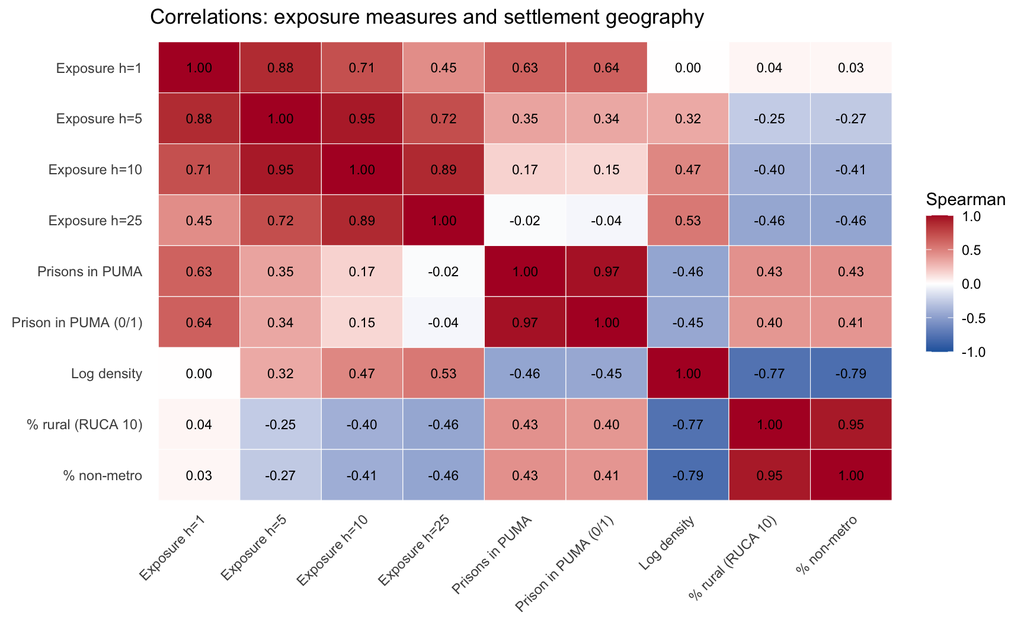

```r
cor_vars <- c(
  # Tract-based measures
  "Exposure h=1"             = "prison_exp_h1",
  "Exposure h=5"             = "prison_exp_h5",
  "Exposure h=10"             = "prison_exp_h10",
  "Exposure h=25"            = "prison_exp_h25",
  "Prisons in PUMA"           = "num_prisons_in_puma",
  "Prison in PUMA (0/1)"      = "prison_present_in_puma",
  # Settlement geography
  "Log density"               = "log_pop_density",
  "% rural (RUCA 10)"         = "pct_pop_rural",
  "% non-metro"               = "pct_pop_nonmetro"
)
cor_vars <- cor_vars[cor_vars %in% names(puma_df)]   # skip any that aren't in the data

cor_mat <- puma_df %>%
  select(all_of(cor_vars)) %>%
  cor(use = "pairwise.complete.obs", method = "spearman")

# correlation matrix code
cor_long <- as_tibble(cor_mat, rownames = "var1") %>%
  pivot_longer(-var1, names_to = "var2", values_to = "rho") %>%
  mutate(var1 = factor(var1, levels = names(cor_vars)),
         var2 = factor(var2, levels = rev(names(cor_vars))))

ggplot(cor_long, aes(var1, var2, fill = rho)) +
  geom_tile(colour = "white") +
  geom_text(aes(label = sprintf("%.2f", rho)), size = 3) +
  scale_fill_gradient2(low = "#2166ac", mid = "white", high = "#b2182b",
                       midpoint = 0, limits = c(-1, 1), name = "Spearman") +
  labs(x = NULL, y = NULL, title = "Correlations: exposure measures and settlement geography") +
  theme_minimal() +
  theme(axis.text.x = element_text(angle = 45, hjust = 1),
        panel.grid = element_blank())
```

## 3.4 Group comparisons

This section shows unadjusted comparisons of the outcomes across exposure groups. Prison presence gives two groups, and the number of prisons gives three (0, 1, 2+). Each decay measure is split into an “unexposed” group (exposure below 0.01, meaning no prison anywhere near where people live) and four equal-sized groups of the exposed PUMAs.

```r
puma_groups <- puma_df %>%
  mutate(
    # 1. Any prison inside the PUMA
    grp_presence = factor(if_else(prison_present_in_puma == 1, "Prison in PUMA", "No prison"),
                          levels = c("No prison", "Prison in PUMA")),
    # 2. Number of prisons inside the PUMA
    grp_count = cut(num_prisons_in_puma, breaks = c(-Inf, 0, 1, Inf),
                    labels = c("0", "1", "2+")),
    # 3. Distance-decay exposure: "unexposed" (< 0.01), then quartiles of the exposed PUMAs
    grp_h1  = if_else(prison_exp_h1  < 0.01, "Unexposed",
                      paste0("Q", ntile(if_else(prison_exp_h1  >= 0.01, prison_exp_h1,  NA_real_), 4))),
    grp_h5  = if_else(prison_exp_h5  < 0.01, "Unexposed",
                      paste0("Q", ntile(if_else(prison_exp_h5  >= 0.01, prison_exp_h5,  NA_real_), 4))),
    grp_h10 = if_else(prison_exp_h10 < 0.01, "Unexposed",
                      paste0("Q", ntile(if_else(prison_exp_h10 >= 0.01, prison_exp_h10, NA_real_), 4))),
    grp_h25 = if_else(prison_exp_h25 < 0.01, "Unexposed",
                      paste0("Q", ntile(if_else(prison_exp_h25 >= 0.01, prison_exp_h25, NA_real_), 4))),
    across(c(grp_h1, grp_h5, grp_h10, grp_h25),
           ~ factor(.x, levels = c("Unexposed", "Q1", "Q2", "Q3", "Q4"))),
    # For the stratified comparison
    metro = factor(if_else(pct_pop_nonmetro > 50, "Non-metro PUMAs", "Metro PUMAs"))
  )

groupings <- c(
  grp_presence = "Prison inside the PUMA",
  grp_count    = "Number of prisons inside the PUMA",
  grp_h1       = "Decay exposure, h = 1 km",
  grp_h5       = "Decay exposure, h = 5 km",
  grp_h10      = "Decay exposure, h = 10 km",
  grp_h25      = "Decay exposure, h = 25 km"
)

# How many PUMAs in each group
puma_groups %>% count(grp_presence)
```

```
    grp_presence    n
1      No prison 1593
2 Prison in PUMA  869
```

```r
puma_groups %>% count(grp_count)
```

```
  grp_count    n
1         0 1593
2         1  411
3        2+  458
```

```r
puma_groups %>% count(grp_h1)
```

```
     grp_h1    n
1 Unexposed 1859
2        Q1  151
3        Q2  151
4        Q3  151
5        Q4  150
```

```r
puma_groups %>% count(grp_h5)
```

```
     grp_h5   n
1 Unexposed 463
2        Q1 500
3        Q2 500
4        Q3 500
5        Q4 499
```

```r
puma_groups %>% count(grp_h10)
```

```
    grp_h10   n
1 Unexposed  55
2        Q1 602
3        Q2 602
4        Q3 602
5        Q4 601
```

```r
puma_groups %>% count(grp_h25)
```

```
    grp_h25   n
1 Unexposed   1
2        Q1 616
3        Q2 615
4        Q3 615
5        Q4 615
```

Mean, median and SD of each outcome in each group:

```r
# All group labels, in display order
group_levels <- c("No prison", "Prison in PUMA", "0", "1", "2+",
                  "Unexposed", "Q1", "Q2", "Q3", "Q4")

# Long format: one row per PUMA x outcome x grouping
group_long <- puma_groups %>%
  select(GEOID20, all_of(names(outcomes)), all_of(names(groupings))) %>%
  pivot_longer(all_of(names(outcomes)), names_to = "y", values_to = "value") %>%
  pivot_longer(all_of(names(groupings)), names_to = "g", values_to = "group",
               values_transform = as.character) %>%
  filter(!is.na(value), !is.na(group)) %>%
  mutate(group = factor(group, levels = group_levels))

group_stats <- group_long %>%
  group_by(y, g, group) %>%
  summarise(n = n(), mean = mean(value), median = median(value), sd = sd(value),
            .groups = "drop") %>%
  mutate(outcome  = outcomes[y],
         grouping = factor(groupings[g], levels = groupings))

group_stats %>%
  select(outcome, grouping, group, n, mean, median, sd) %>%
  arrange(outcome, grouping, group) %>%
  gt(groupname_col = c("outcome", "grouping")) %>%
  fmt_number(columns = c(mean, median, sd), decimals = 2) %>%
  tab_header(title = "Outcomes by prison exposure group")
```

Outcomes by prison exposure group

| group | n | mean | median | sd |
| --- | --- | --- | --- | --- |
| % of ever-married divorced in past year - Prison inside the PUMA |  |  |  |  |
| No prison | 1593 | 1.04 | 0.98 | 0.44 |
| Prison in PUMA | 869 | 1.10 | 1.03 | 0.41 |
| % of ever-married divorced in past year - Number of prisons inside the PUMA |  |  |  |  |
| 0 | 1593 | 1.04 | 0.98 | 0.44 |
| 1 | 411 | 1.11 | 1.05 | 0.43 |
| 2+ | 458 | 1.09 | 1.01 | 0.39 |
| % of ever-married divorced in past year - Decay exposure, h = 1 km |  |  |  |  |
| Unexposed | 1859 | 1.02 | 0.97 | 0.41 |
| Q1 | 151 | 1.09 | 1.01 | 0.46 |
| Q2 | 151 | 1.09 | 1.09 | 0.41 |
| Q3 | 151 | 1.18 | 1.08 | 0.48 |
| Q4 | 150 | 1.30 | 1.24 | 0.50 |
| % of ever-married divorced in past year - Decay exposure, h = 5 km |  |  |  |  |
| Unexposed | 463 | 1.03 | 0.99 | 0.40 |
| Q1 | 500 | 0.98 | 0.95 | 0.39 |
| Q2 | 500 | 1.03 | 0.96 | 0.40 |
| Q3 | 500 | 1.04 | 1.00 | 0.40 |
| Q4 | 499 | 1.21 | 1.14 | 0.51 |
| % of ever-married divorced in past year - Decay exposure, h = 10 km |  |  |  |  |
| Unexposed | 55 | 1.10 | 1.08 | 0.39 |
| Q1 | 602 | 1.00 | 0.96 | 0.38 |
| Q2 | 602 | 1.03 | 0.98 | 0.41 |
| Q3 | 602 | 1.02 | 0.98 | 0.40 |
| Q4 | 601 | 1.17 | 1.10 | 0.50 |
| % of ever-married divorced in past year - Decay exposure, h = 25 km |  |  |  |  |
| Unexposed | 1 | 0.90 | 0.90 | NA |
| Q1 | 616 | 1.04 | 0.98 | 0.39 |
| Q2 | 615 | 1.04 | 0.99 | 0.41 |
| Q3 | 615 | 1.06 | 1.01 | 0.42 |
| Q4 | 615 | 1.10 | 1.02 | 0.49 |
| Overdose deaths per 100,000 - Prison inside the PUMA |  |  |  |  |
| No prison | 1593 | 26.45 | 22.00 | 17.44 |
| Prison in PUMA | 869 | 29.46 | 24.67 | 19.18 |
| Overdose deaths per 100,000 - Number of prisons inside the PUMA |  |  |  |  |
| 0 | 1593 | 26.45 | 22.00 | 17.44 |
| 1 | 411 | 28.45 | 24.32 | 18.27 |
| 2+ | 458 | 30.36 | 24.84 | 19.94 |
| Overdose deaths per 100,000 - Decay exposure, h = 1 km |  |  |  |  |
| Unexposed | 1859 | 26.36 | 22.15 | 16.04 |
| Q1 | 151 | 27.63 | 23.28 | 16.65 |
| Q2 | 151 | 27.81 | 25.96 | 17.02 |
| Q3 | 151 | 30.33 | 25.03 | 20.65 |
| Q4 | 150 | 38.55 | 30.17 | 32.70 |
| Overdose deaths per 100,000 - Decay exposure, h = 5 km |  |  |  |  |
| Unexposed | 463 | 26.00 | 21.90 | 16.34 |
| Q1 | 500 | 25.15 | 19.87 | 17.27 |
| Q2 | 500 | 26.21 | 22.64 | 14.66 |
| Q3 | 500 | 28.00 | 24.75 | 14.59 |
| Q4 | 499 | 32.09 | 26.71 | 24.86 |
| Overdose deaths per 100,000 - Decay exposure, h = 10 km |  |  |  |  |
| Unexposed | 55 | 21.92 | 17.85 | 13.15 |
| Q1 | 602 | 26.20 | 21.65 | 17.28 |
| Q2 | 602 | 26.41 | 21.58 | 16.39 |
| Q3 | 602 | 27.06 | 24.49 | 14.02 |
| Q4 | 601 | 30.88 | 25.62 | 23.44 |
| Overdose deaths per 100,000 - Decay exposure, h = 25 km |  |  |  |  |
| Unexposed | 1 | 14.85 | 14.85 | NA |
| Q1 | 616 | 25.38 | 20.62 | 17.10 |
| Q2 | 615 | 28.05 | 24.04 | 16.80 |
| Q3 | 615 | 28.29 | 24.45 | 15.75 |
| Q4 | 615 | 28.35 | 23.23 | 22.07 |

```r
# Two groups (prison in PUMA vs not): Welch t-test and Wilcoxon rank-sum test
tests_presence <- group_long %>%
  filter(g == "grp_presence") %>%
  group_by(y, g) %>%
  summarise(
    test_means = "Welch t-test",
    difference = diff(t.test(value ~ droplevels(group))$estimate),   # prison minus no prison
    p_means    = t.test(value ~ droplevels(group))$p.value,
    test_ranks = "Wilcoxon",
    p_ranks    = wilcox.test(value ~ droplevels(group))$p.value,
    p_trend    = NA_real_,
    .groups = "drop"
  )

# More than two ordered groups (count and all decay measures):
# ANOVA, Kruskal-Wallis and a linear trend test across the ordered groups
tests_ordered <- group_long %>%
  filter(g != "grp_presence") %>%
  group_by(y, g) %>%
  summarise(
    test_means = "ANOVA",
    difference = NA_real_,
    p_means    = anova(lm(value ~ droplevels(group)))$`Pr(>F)`[1],
    test_ranks = "Kruskal-Wallis",
    p_ranks    = kruskal.test(value ~ droplevels(group))$p.value,
    p_trend    = tidy(lm(value ~ as.integer(droplevels(group))))$p.value[2],   # groups as 1, 2, 3, ...
    .groups = "drop"
  )

test_results <- bind_rows(tests_presence, tests_ordered) %>%
  mutate(outcome  = outcomes[y],
         grouping = factor(groupings[g], levels = groupings)) %>%
  arrange(outcome, grouping) %>%
  select(outcome, grouping, test_means, difference, p_means, test_ranks, p_ranks, p_trend)

test_results %>%
  gt(groupname_col = "outcome") %>%
  fmt_number(columns = difference, decimals = 2) %>%
  fmt_number(columns = c(p_means, p_ranks, p_trend), decimals = 4) %>%
  sub_missing(missing_text = "") %>%
  cols_label(grouping = "Grouping", test_means = "Means test", difference = "Difference",
             p_means = "p (means)", test_ranks = "Rank test", p_ranks = "p (ranks)",
             p_trend = "p (linear trend)") %>%
  tab_header(title = "Do outcomes differ by prison exposure? (unadjusted)",
subtitle = "Difference = with prison minus without (two-group comparisons only)")
```

Do outcomes differ by prison exposure? (unadjusted)

Difference = with prison minus without (two-group comparisons only)

| Grouping | Means test | Difference | p (means) | Rank test | p (ranks) | p (linear trend) |
| --- | --- | --- | --- | --- | --- | --- |
| % of ever-married divorced in past year |  |  |  |  |  |  |
| Prison inside the PUMA | Welch t-test | 0.06 | 0.0003 | Wilcoxon | 0.0000 |  |
| Number of prisons inside the PUMA | ANOVA |  | 0.0015 | Kruskal-Wallis | 0.0001 | 0.0023 |
| Decay exposure, h = 1 km | ANOVA |  | 0.0000 | Kruskal-Wallis | 0.0000 | 0.0000 |
| Decay exposure, h = 5 km | ANOVA |  | 0.0000 | Kruskal-Wallis | 0.0000 | 0.0000 |
| Decay exposure, h = 10 km | ANOVA |  | 0.0000 | Kruskal-Wallis | 0.0000 | 0.0000 |
| Decay exposure, h = 25 km | ANOVA |  | 0.1019 | Kruskal-Wallis | 0.5834 | 0.0101 |
| Overdose deaths per 100,000 |  |  |  |  |  |  |
| Prison inside the PUMA | Welch t-test | 3.01 | 0.0001 | Wilcoxon | 0.0001 |  |
| Number of prisons inside the PUMA | ANOVA |  | 0.0001 | Kruskal-Wallis | 0.0002 | 0.0000 |
| Decay exposure, h = 1 km | ANOVA |  | 0.0000 | Kruskal-Wallis | 0.0017 | 0.0000 |
| Decay exposure, h = 5 km | ANOVA |  | 0.0000 | Kruskal-Wallis | 0.0000 | 0.0000 |
| Decay exposure, h = 10 km | ANOVA |  | 0.0000 | Kruskal-Wallis | 0.0001 | 0.0000 |
| Decay exposure, h = 25 km | ANOVA |  | 0.0173 | Kruskal-Wallis | 0.0001 | 0.0047 |

These tests check whether the outcomes differ across groups. For the two-group comparison (prison vs. no prison), we used a Welch t-test for the means and a Wilcoxon rank-sum test for the whole distributions. For the groupings with more than two groups, we used ANOVA and Kruskal-Wallis, plus a linear trend test across the ordered groups. These tests ignore the controls and assume that PUMAs are independent (they are not), so they are descriptive only.

### 3.4.1 Within metro and non-metro PUMAs

The same prison vs. no prison comparison, separately for metro and non-metro PUMAs.

```r
# Prison vs. no prison, separately in metro and non-metro PUMAs.
# Welch t-test (means) and Wilcoxon rank-sum test (distributions), as in the main comparison.
stratified <- puma_groups %>%
  pivot_longer(all_of(names(outcomes)), names_to = "y", values_to = "value") %>%
  filter(!is.na(value), !is.na(grp_presence)) %>%
  group_by(y, metro) %>%
  summarise(
    n_no_prison    = sum(grp_presence == "No prison"),
    n_prison       = sum(grp_presence == "Prison in PUMA"),
    mean_no_prison = t.test(value ~ grp_presence)$estimate[[1]],
    mean_prison    = t.test(value ~ grp_presence)$estimate[[2]],
    difference     = mean_prison - mean_no_prison,              # prison minus no prison
    p_means        = t.test(value ~ grp_presence)$p.value,
    p_ranks        = wilcox.test(value ~ grp_presence)$p.value,
    .groups = "drop"
  ) %>%
  mutate(outcome = outcomes[y])

stratified %>%
  select(outcome, metro, n_no_prison, n_prison, mean_no_prison, mean_prison,
         difference, p_means, p_ranks) %>%
  arrange(outcome, metro) %>%
  gt(groupname_col = "outcome") %>%
  fmt_number(columns = c(mean_no_prison, mean_prison, difference), decimals = 2) %>%
  fmt_number(columns = c(p_means, p_ranks), decimals = 4) %>%
  cols_label(metro = "PUMAs", n_no_prison = "n (no prison)", n_prison = "n (prison)",
             mean_no_prison = "Mean (no prison)", mean_prison = "Mean (prison)",
             difference = "Difference", p_means = "p (t-test)", p_ranks = "p (Wilcoxon)") %>%
  tab_header(title = "Prison vs. no prison, within metro and non-metro PUMAs (unadjusted)")
```

Prison vs. no prison, within metro and non-metro PUMAs (unadjusted)

| PUMAs | n (no prison) | n (prison) | Mean (no prison) | Mean (prison) | Difference | p (t-test) | p (Wilcoxon) |
| --- | --- | --- | --- | --- | --- | --- | --- |
| % of ever-married divorced in past year |  |  |  |  |  |  |  |
| Metro PUMAs | 1477 | 584 | 1.04 | 1.13 | 0.10 | 0.0000 | 0.0000 |
| Non-metro PUMAs | 116 | 285 | 1.03 | 1.04 | 0.01 | 0.8732 | 0.9746 |
| Overdose deaths per 100,000 |  |  |  |  |  |  |  |
| Metro PUMAs | 1477 | 584 | 26.41 | 31.35 | 4.93 | 0.0000 | 0.0000 |
| Non-metro PUMAs | 116 | 285 | 26.89 | 25.59 | −1.31 | 0.4270 | 0.1735 |

I think this is actually interesting, but unfortunately it contradicts my initial theory. First of all, there are more prisons in urban/metropolitan areas (which makes sense given the way we define metro/non-metro). However, what is more important is that the means are actually lower (for overdose) or not significantly different (for divorce) in the rural PUMAs with prisons.

# 4 OLS MODELS

Each model has one exposure measure. Controls are added in stages so we can see how much the exposure coefficient moves at each step. Standard errors for all of the models are clustered by state

| Model | Adds |
| --- | --- |
| M1 | nothing (exposure only) |
| M2 | settlement geography: log density, % non-metro, log population |
| M3a | M2 + economic: % unemployed, log median income |
| M3b | M2 + education: % bachelor’s or more |
| M3c | M2 + race: % non-White |
| M3d | M2 + all of the above |
| M3 | M3d + state fixed effects |
| M3-div | M3d + Census division fixed effects |

## 4.1 Setup and fitting

```r
# Census division for each state (base R state lists; DC added by hand)
state_lookup <- tibble(state = state.abb,
                       division = as.character(state.division)) %>%
  add_row(state = "DC", division = "South Atlantic") %>%
  left_join(distinct(tidycensus::fips_codes, state, state_code), by = "state") %>%
  select(state_fips = state_code, division)

# Exposure measures: variable -> label
exposures <- c(
  prison_exp_h1          = "Exposure, h = 1 km",
  prison_exp_h5          = "Exposure, h = 5 km",
  prison_exp_h10         = "Exposure, h = 10 km",
  prison_exp_h25         = "Exposure, h = 25 km",
  num_prisons_in_puma    = "Number of prisons in PUMA",
  prison_present_in_puma = "Prison in PUMA (0/1)"
)

# Control groups
ctrl_geo  <- c("log_pop_density", "pct_pop_nonmetro", "log_pop")
ctrl_econ <- c("pct_unemployed", "log_medhhinc")
ctrl_educ <- c("pct_bachelors_plus")
ctrl_race <- c("pct_nonwhite")
ctrl_religion <-c("pct_religious")
ctrl_all  <- c(ctrl_geo, ctrl_econ, ctrl_educ, ctrl_race)
ctrl_all_div  <- c(ctrl_geo, ctrl_econ, ctrl_educ, ctrl_race, ctrl_religion)

# Model specifications: one row per stage, with its controls and fixed effects
specs_od <- tibble(
  spec     = c("M1", "M2", "M3a", "M3b", "M3c", "M3d", "M3", "M3-div"),
  controls = list(character(0), ctrl_geo, c(ctrl_geo, ctrl_econ), c(ctrl_geo, ctrl_educ),
                  c(ctrl_geo, ctrl_race), ctrl_all, ctrl_all, ctrl_all),
  fe       = c(NA, NA, NA, NA, NA, NA, "state_fips", "division")
)

specs_div <- tibble(
  spec     = c("M1", "M2", "M3a", "M3b", "M3c", "M3d", "M3", "M3-div"),
  controls = list(character(0), ctrl_geo, c(ctrl_geo, ctrl_econ), c(ctrl_geo, ctrl_educ),
                  c(ctrl_geo, ctrl_race), ctrl_all_div, ctrl_all_div, ctrl_all_div),
  fe       = c(NA, NA, NA, NA, NA, NA, "state_fips", "division")
)

# Both together, with the outcome each set of specs belongs to
specs <- bind_rows(
  specs_od  %>% mutate(y = "overdose_rate_2022_2024"),
  specs_div %>% mutate(y = "pct_divorced_past_yr")
)

# Model data: add division and log distance; standardize continuous exposures
puma_m <- puma_df %>%
  left_join(state_lookup, by = "state_fips") %>%
  mutate(log_dist_nearest = log(dist_nearest_prison_km_popw),
         across(all_of(setdiff(names(exposures), "prison_present_in_puma")),
                ~ (.x - mean(.x, na.rm = TRUE)) / sd(.x, na.rm = TRUE)))

# One complete-case sample per outcome, using that outcome's own full control set
# (same PUMAs in every model for that outcome)
model_data <- list(
  overdose_rate_2022_2024 = puma_m %>%
    drop_na(all_of(c("overdose_rate_2022_2024", names(exposures), ctrl_all,
                     "state_fips", "division"))),
  pct_divorced_past_yr = puma_m %>%
    drop_na(all_of(c("pct_divorced_past_yr", names(exposures), ctrl_all_div,
                     "state_fips", "division")))
)

map_int(model_data, nrow)   # PUMAs per outcome
```

```
overdose_rate_2022_2024    pct_divorced_past_yr
                   2462                    2462
```

```r
# Every outcome x specification (its own specs) x exposure, with its formula written out
all_models <- specs %>%
  expand_grid(x = names(exposures)) %>%
  mutate(
    rhs     = map2_chr(x, controls, ~ str_c(c(.x, .y), collapse = " + ")),
    formula = str_c(y, " ~ ", rhs, if_else(is.na(fe), "", str_c(" | ", fe))),
    model   = map2(formula, y, ~ feols(as.formula(.x), data = model_data[[.y]],
                                       cluster = ~state_fips))
  )

all_models %>% distinct(y, spec, formula)   # check: the divorce M3d/M3/M3-div should include the extra controls
```

```
# A tibble: 96 × 3
   y                       spec  formula
   <chr>                   <chr> <chr>
 1 overdose_rate_2022_2024 M1    overdose_rate_2022_2024 ~ prison_exp_h1
 2 overdose_rate_2022_2024 M1    overdose_rate_2022_2024 ~ prison_exp_h5
 3 overdose_rate_2022_2024 M1    overdose_rate_2022_2024 ~ prison_exp_h10
 4 overdose_rate_2022_2024 M1    overdose_rate_2022_2024 ~ prison_exp_h25
 5 overdose_rate_2022_2024 M1    overdose_rate_2022_2024 ~ num_prisons_in_puma
 6 overdose_rate_2022_2024 M1    overdose_rate_2022_2024 ~ prison_present_in_pu…
 7 overdose_rate_2022_2024 M2    overdose_rate_2022_2024 ~ prison_exp_h1 + log_…
 8 overdose_rate_2022_2024 M2    overdose_rate_2022_2024 ~ prison_exp_h5 + log_…
 9 overdose_rate_2022_2024 M2    overdose_rate_2022_2024 ~ prison_exp_h10 + log…
10 overdose_rate_2022_2024 M2    overdose_rate_2022_2024 ~ prison_exp_h25 + log…
# ℹ 86 more rows
```

```r
# Pull out the exposure coefficient from each model
results <- all_models %>%
  mutate(
    coef = map2(model, x, ~ tidy(.x, conf.int = TRUE) %>%
                              filter(term == .y) %>%
                              select(estimate, std.error, p.value, conf.low, conf.high)),
    r2 = map_dbl(model, ~ r2(.x, "r2")),
    n  = map_int(model, nobs)
  ) %>%
  select(y, x, spec, coef, r2, n) %>%
  unnest(coef) %>%
    mutate(spec = factor(spec, levels = specs_od$spec)) %>%
  group_by(y, x) %>%
  arrange(spec, .by_group = TRUE) %>%
  mutate(pct_change_from_M1 = 100 * (estimate - first(estimate)) / abs(first(estimate))) %>%
  ungroup() %>%
  mutate(outcome  = outcomes[y],
         exposure = factor(exposures[x], levels = exposures))
```

## 4.2 All stages, by exposure

Each table is one exposure measure across all model stages, so we can see how β, its standard error and R² change as controls are added.

### 4.2.1 Overdose deaths per 100,000

h = 1 km:

Positive association between the overdose rate and prison_exp_h1, significant under all specifications.

```r
models_od <- all_models %>%
  filter(y == "overdose_rate_2022_2024", x == "prison_exp_h1") %>%
  pull(model) %>%
  set_names(specs_od$spec)

etable(models_od, fitstat = ~ r2 + n, digits = 3)
```

```
                                        M1                      M2
Dependent Var.:    overdose_rate_2022_2024 overdose_rate_2022_2024

Constant                    27.5*** (1.36)           143.3* (55.0)
prison_exp_h1                 4.13* (1.65)           3.99** (1.42)
log_pop_density                                       0.143 (1.09)
pct_pop_nonmetro                                    -0.016 (0.041)
log_pop                                              -9.87* (4.26)
pct_unemployed
log_medhhinc
pct_bachelors_plus
pct_nonwhite
Fixed-Effects:     ----------------------- -----------------------
state_fips                              No                      No
division                                No                      No
__________________ _______________________ _______________________
S.E.: Clustered             by: state_fips          by: state_fips
R2                                 0.05198                 0.06397
Observations                         2,462                   2,462

                                       M3a                     M3b
Dependent Var.:    overdose_rate_2022_2024 overdose_rate_2022_2024

Constant                   374.8*** (83.1)          158.2** (54.8)
prison_exp_h1                 3.11* (1.44)           3.93** (1.46)
log_pop_density              -0.080 (1.00)            0.790 (1.20)
pct_pop_nonmetro           -0.102* (0.042)          -0.059 (0.042)
log_pop                      -8.80. (4.39)           -10.2* (4.20)
pct_unemployed               0.905 (0.757)
log_medhhinc               -21.8*** (4.25)
pct_bachelors_plus                               -0.375*** (0.077)
pct_nonwhite
Fixed-Effects:     ----------------------- -----------------------
state_fips                              No                      No
division                                No                      No
__________________ _______________________ _______________________
S.E.: Clustered             by: state_fips          by: state_fips
R2                                 0.22623                 0.14780
Observations                         2,462                   2,462

```

[output cut: 26 more lines]

```
pct_pop_nonmetro           -0.124* (0.052)        -0.122** (0.044)
log_pop                       -5.90 (4.87)           -9.09. (4.56)
pct_unemployed                 1.32 (1.11)           1.63. (0.942)
log_medhhinc               -26.1*** (4.90)         -25.5*** (3.82)
pct_bachelors_plus          -0.027 (0.047)          -0.035 (0.046)
pct_nonwhite             -0.174*** (0.045)       -0.223*** (0.039)
Fixed-Effects:     ----------------------- -----------------------
state_fips                             Yes                      No
division                                No                     Yes
__________________ _______________________ _______________________
S.E.: Clustered             by: state_fips          by: state_fips
R2                                 0.42300                 0.32737
Observations                         2,462                   2,462
---
Signif. codes: 0 '***' 0.001 '**' 0.01 '*' 0.05 '.' 0.1 ' ' 1
```

h = 5 km:

Positive association between the overdose rate and prison_exp_h5, NOT significant under any specification.

```r
models_od <- all_models %>%
  filter(y == "overdose_rate_2022_2024", x == "prison_exp_h5") %>%
  pull(model) %>%
  set_names(specs_od$spec)

etable(models_od, fitstat = ~ r2 + n, digits = 3)
```

```
                                        M1                      M2
Dependent Var.:    overdose_rate_2022_2024 overdose_rate_2022_2024

Constant                    27.5*** (1.33)           142.7* (58.3)
prison_exp_h5                 3.84. (2.28)            3.77. (2.01)
log_pop_density                                     -0.133 (0.999)
pct_pop_nonmetro                                    -0.014 (0.042)
log_pop                                              -9.68* (4.55)
pct_unemployed
log_medhhinc
pct_bachelors_plus
pct_nonwhite
Fixed-Effects:     ----------------------- -----------------------
state_fips                              No                      No
division                                No                      No
__________________ _______________________ _______________________
S.E.: Clustered             by: state_fips          by: state_fips
R2                                 0.04496                 0.05520
Observations                         2,462                   2,462

                                       M3a                     M3b
Dependent Var.:    overdose_rate_2022_2024 overdose_rate_2022_2024

Constant                   372.6*** (87.7)          157.5** (58.2)
prison_exp_h5                  2.64 (2.11)            3.67. (2.02)
log_pop_density             -0.247 (0.928)            0.527 (1.11)
pct_pop_nonmetro           -0.099* (0.044)          -0.056 (0.044)
log_pop                      -8.70. (4.61)           -10.0* (4.49)
pct_unemployed               0.951 (0.775)
log_medhhinc               -21.6*** (4.37)
pct_bachelors_plus                               -0.374*** (0.077)
pct_nonwhite
Fixed-Effects:     ----------------------- -----------------------
state_fips                              No                      No
division                                No                      No
__________________ _______________________ _______________________
S.E.: Clustered             by: state_fips          by: state_fips
R2                                 0.21651                 0.13818
Observations                         2,462                   2,462

```

[output cut: 26 more lines]

```
pct_pop_nonmetro           -0.124* (0.053)        -0.121** (0.045)
log_pop                       -5.92 (4.96)           -9.00. (4.74)
pct_unemployed                 1.37 (1.14)           1.70. (0.986)
log_medhhinc               -26.3*** (5.16)         -25.7*** (4.04)
pct_bachelors_plus          -0.026 (0.051)          -0.032 (0.050)
pct_nonwhite             -0.186*** (0.047)       -0.234*** (0.042)
Fixed-Effects:     ----------------------- -----------------------
state_fips                             Yes                      No
division                                No                     Yes
__________________ _______________________ _______________________
S.E.: Clustered             by: state_fips          by: state_fips
R2                                 0.41485                 0.31838
Observations                         2,462                   2,462
---
Signif. codes: 0 '***' 0.001 '**' 0.01 '*' 0.05 '.' 0.1 ' ' 1
```

h = 10 km:

Positive association between the overdose rate and prison_exp_h10, NOT significant under any specification.

```r
models_od <- all_models %>%
  filter(y == "overdose_rate_2022_2024", x == "prison_exp_h10") %>%
  pull(model) %>%
  set_names(specs_od$spec)

etable(models_od, fitstat = ~ r2 + n, digits = 3)
```

```
                                        M1                      M2
Dependent Var.:    overdose_rate_2022_2024 overdose_rate_2022_2024

Constant                    27.5*** (1.35)           141.7* (58.1)
prison_exp_h10                 2.69 (2.36)             2.49 (2.25)
log_pop_density                                      0.063 (0.926)
pct_pop_nonmetro                                    -0.007 (0.042)
log_pop                                              -9.70* (4.57)
pct_unemployed
log_medhhinc
pct_bachelors_plus
pct_nonwhite
Fixed-Effects:     ----------------------- -----------------------
state_fips                              No                      No
division                                No                      No
__________________ _______________________ _______________________
S.E.: Clustered             by: state_fips          by: state_fips
R2                                 0.02205                 0.03245
Observations                         2,462                   2,462

                                       M3a                     M3b
Dependent Var.:    overdose_rate_2022_2024 overdose_rate_2022_2024

Constant                   379.5*** (86.7)          156.7** (58.1)
prison_exp_h10                 1.75 (2.34)             2.52 (2.28)
log_pop_density             -0.116 (0.864)            0.701 (1.05)
pct_pop_nonmetro           -0.097* (0.043)          -0.050 (0.043)
log_pop                      -8.68. (4.67)           -10.0* (4.52)
pct_unemployed               0.960 (0.773)
log_medhhinc               -22.3*** (4.38)
pct_bachelors_plus                               -0.379*** (0.080)
pct_nonwhite
Fixed-Effects:     ----------------------- -----------------------
state_fips                              No                      No
division                                No                      No
__________________ _______________________ _______________________
S.E.: Clustered             by: state_fips          by: state_fips
R2                                 0.20577                 0.11801
Observations                         2,462                   2,462

```

[output cut: 26 more lines]

```
pct_pop_nonmetro           -0.123* (0.051)        -0.119** (0.043)
log_pop                       -5.81 (4.97)           -8.93. (4.82)
pct_unemployed                 1.39 (1.13)           1.70. (0.981)
log_medhhinc               -27.7*** (4.93)         -27.0*** (3.74)
pct_bachelors_plus          -0.008 (0.049)          -0.013 (0.047)
pct_nonwhite             -0.179*** (0.047)       -0.230*** (0.043)
Fixed-Effects:     ----------------------- -----------------------
state_fips                             Yes                      No
division                                No                     Yes
__________________ _______________________ _______________________
S.E.: Clustered             by: state_fips          by: state_fips
R2                                 0.40663                 0.30815
Observations                         2,462                   2,462
---
Signif. codes: 0 '***' 0.001 '**' 0.01 '*' 0.05 '.' 0.1 ' ' 1
```

Number of prisons in the PUMA:

Positive association between the overdose rate and num_prisons_in_puma, NOT significant under full specifications.

```r
models_od <- all_models %>%
  filter(y == "overdose_rate_2022_2024", x == "num_prisons_in_puma") %>%
  pull(model) %>%
  set_names(specs_od$spec)

etable(models_od, fitstat = ~ r2 + n, digits = 3)
```

```
                                         M1                      M2
Dependent Var.:     overdose_rate_2022_2024 overdose_rate_2022_2024

Constant                     27.5*** (1.43)          152.5** (54.1)
num_prisons_in_puma           1.09. (0.589)          2.21** (0.693)
log_pop_density                                         1.00 (1.20)
pct_pop_nonmetro                                     -0.013 (0.040)
log_pop                                               -11.1* (4.20)
pct_unemployed
log_medhhinc
pct_bachelors_plus
pct_nonwhite
Fixed-Effects:      ----------------------- -----------------------
state_fips                               No                      No
division                                 No                      No
___________________ _______________________ _______________________
S.E.: Clustered              by: state_fips          by: state_fips
R2                                  0.00362                 0.02953
Observations                          2,462                   2,462

                                        M3a                     M3b
Dependent Var.:     overdose_rate_2022_2024 overdose_rate_2022_2024

Constant                    387.6*** (81.2)          165.7** (54.3)
num_prisons_in_puma           1.02. (0.601)          1.84** (0.664)
log_pop_density                0.482 (1.08)             1.58 (1.31)
pct_pop_nonmetro            -0.099* (0.042)          -0.053 (0.042)
log_pop                       -9.41* (4.43)          -11.3** (4.17)
pct_unemployed                0.906 (0.752)
log_medhhinc                -22.5*** (4.32)
pct_bachelors_plus                                -0.371*** (0.079)
pct_nonwhite
Fixed-Effects:      ----------------------- -----------------------
state_fips                               No                      No
division                                 No                      No
___________________ _______________________ _______________________
S.E.: Clustered              by: state_fips          by: state_fips
R2                                  0.20087                 0.11088
Observations                          2,462                   2,462

```

[output cut: 26 more lines]

```
pct_pop_nonmetro            -0.125* (0.051)        -0.120** (0.043)
log_pop                        -6.15 (4.95)           -9.51* (4.67)
pct_unemployed                  1.35 (1.09)           1.65. (0.931)
log_medhhinc                -27.6*** (4.68)         -27.3*** (3.55)
pct_bachelors_plus           -0.003 (0.045)          -0.004 (0.047)
pct_nonwhite              -0.167*** (0.044)       -0.217*** (0.039)
Fixed-Effects:      ----------------------- -----------------------
state_fips                              Yes                      No
division                                 No                     Yes
___________________ _______________________ _______________________
S.E.: Clustered              by: state_fips          by: state_fips
R2                                  0.40678                 0.30507
Observations                          2,462                   2,462
---
Signif. codes: 0 '***' 0.001 '**' 0.01 '*' 0.05 '.' 0.1 ' ' 1
```

Any prison in the PUMA:

```r
models_od <- all_models %>%
  filter(y == "overdose_rate_2022_2024", x == "prison_present_in_puma") %>%
  pull(model) %>%
  set_names(specs_od$spec)

etable(models_od, fitstat = ~ r2 + n, digits = 3)
```

```
                                            M1                      M2
Dependent Var.:        overdose_rate_2022_2024 overdose_rate_2022_2024

Constant                        26.4*** (1.43)          150.8** (53.9)
prison_present_in_puma            3.01* (1.34)          5.85*** (1.41)
log_pop_density                                            1.19 (1.22)
pct_pop_nonmetro                                        -0.012 (0.040)
log_pop                                                 -11.2** (4.15)
pct_unemployed
log_medhhinc
pct_bachelors_plus
pct_nonwhite
Fixed-Effects:         ----------------------- -----------------------
state_fips                                  No                      No
division                                    No                      No
______________________ _______________________ _______________________
S.E.: Clustered                 by: state_fips          by: state_fips
R2                                     0.00629                 0.03609
Observations                             2,462                   2,462

                                           M3a                     M3b
Dependent Var.:        overdose_rate_2022_2024 overdose_rate_2022_2024

Constant                       382.3*** (82.3)          163.7** (54.3)
prison_present_in_puma            2.44. (1.22)           4.60** (1.36)
log_pop_density                   0.533 (1.08)             1.70 (1.31)
pct_pop_nonmetro               -0.097* (0.042)          -0.052 (0.042)
log_pop                          -9.44* (4.37)          -11.3** (4.13)
pct_unemployed                   0.945 (0.754)
log_medhhinc                   -22.1*** (4.42)
pct_bachelors_plus                                   -0.364*** (0.078)
pct_nonwhite
Fixed-Effects:         ----------------------- -----------------------
state_fips                                  No                      No
division                                    No                      No
______________________ _______________________ _______________________
S.E.: Clustered                 by: state_fips          by: state_fips
R2                                     0.20149                 0.11394
Observations                             2,462                   2,462

```

[output cut: 26 more lines]

```
pct_pop_nonmetro               -0.122* (0.051)        -0.118** (0.043)
log_pop                           -6.12 (4.96)           -9.51* (4.65)
pct_unemployed                     1.37 (1.10)           1.69. (0.933)
log_medhhinc                   -27.5*** (4.73)         -27.1*** (3.58)
pct_bachelors_plus             -0.0007 (0.046)          -0.003 (0.046)
pct_nonwhite                 -0.167*** (0.045)       -0.217*** (0.039)
Fixed-Effects:         ----------------------- -----------------------
state_fips                                 Yes                      No
division                                    No                     Yes
______________________ _______________________ _______________________
S.E.: Clustered                 by: state_fips          by: state_fips
R2                                     0.40627                 0.30499
Observations                             2,462                   2,462
---
Signif. codes: 0 '***' 0.001 '**' 0.01 '*' 0.05 '.' 0.1 ' ' 1
```

### 4.2.2 % of ever-married divorced in the past year

From M3d on, the divorce models also control for religious adherence (`pct_religious`).

h = 1 km:

Positive association between the divorce rate and prison_exp_h1, significant under all specifications.

```r
models_div <- all_models %>%
  filter(y == "pct_divorced_past_yr", x == "prison_exp_h1") %>%
  pull(model) %>%
  set_names(specs_div$spec)

etable(models_div, fitstat = ~ r2 + n, digits = 3)
```

```
                                     M1                   M2
Dependent Var.:    pct_divorced_past_yr pct_divorced_past_yr

Constant                1.06*** (0.021)        1.58* (0.607)
prison_exp_h1          0.072*** (0.014)     0.062*** (0.013)
log_pop_density                              0.034** (0.010)
pct_pop_nonmetro                            0.001** (0.0004)
log_pop                                       -0.062 (0.051)
pct_unemployed
log_medhhinc
pct_bachelors_plus
pct_nonwhite
pct_religious
Fixed-Effects:     -------------------- --------------------
state_fips                           No                   No
division                             No                   No
__________________ ____________________ ____________________
S.E.: Clustered          by: state_fips       by: state_fips
R2                              0.02790              0.04038
Observations                      2,462                2,462

                                    M3a                  M3b
Dependent Var.:    pct_divorced_past_yr pct_divorced_past_yr

Constant                 6.86*** (1.16)       1.90** (0.666)
prison_exp_h1          0.043*** (0.010)     0.061*** (0.013)
log_pop_density         0.030** (0.010)     0.048*** (0.012)
pct_pop_nonmetro       -0.0006 (0.0004)      0.0003 (0.0004)
log_pop                  -0.038 (0.067)       -0.070 (0.055)
pct_unemployed           0.016* (0.007)
log_medhhinc          -0.495*** (0.052)
pct_bachelors_plus                         -0.008*** (0.001)
pct_nonwhite
pct_religious
Fixed-Effects:     -------------------- --------------------
state_fips                           No                   No
division                             No                   No
__________________ ____________________ ____________________
S.E.: Clustered          by: state_fips       by: state_fips
R2                              0.18146              0.11196
```

[output cut: 30 more lines]

```
log_pop                   0.002 (0.063)       -0.021 (0.062)
pct_unemployed           0.026* (0.010)       0.022* (0.010)
log_medhhinc          -0.405*** (0.058)    -0.423*** (0.062)
pct_bachelors_plus     -0.0002 (0.0010)     -8.42e-5 (0.001)
pct_nonwhite              0.001 (0.001)       0.0006 (0.001)
pct_religious            -0.001 (0.001)      -0.002* (0.001)
Fixed-Effects:     -------------------- --------------------
state_fips                          Yes                   No
division                             No                  Yes
__________________ ____________________ ____________________
S.E.: Clustered          by: state_fips       by: state_fips
R2                              0.25872              0.22402
Observations                      2,462                2,462
---
Signif. codes: 0 '***' 0.001 '**' 0.01 '*' 0.05 '.' 0.1 ' ' 1
```

h = 5 km:

Positive association between the divorce rate and prison_exp_h5, significant under all specifications.

```r
models_div <- all_models %>%
  filter(y == "pct_divorced_past_yr", x == "prison_exp_h5") %>%
  pull(model) %>%
  set_names(specs_div$spec)

etable(models_div, fitstat = ~ r2 + n, digits = 3)
```

```
                                     M1                   M2
Dependent Var.:    pct_divorced_past_yr pct_divorced_past_yr

Constant                1.06*** (0.021)        1.56* (0.619)
prison_exp_h5          0.085*** (0.011)     0.074*** (0.014)
log_pop_density                               0.026* (0.011)
pct_pop_nonmetro                            0.001** (0.0004)
log_pop                                       -0.057 (0.052)
pct_unemployed
log_medhhinc
pct_bachelors_plus
pct_nonwhite
pct_religious
Fixed-Effects:     -------------------- --------------------
state_fips                           No                   No
division                             No                   No
__________________ ____________________ ____________________
S.E.: Clustered          by: state_fips       by: state_fips
R2                              0.03871              0.04596
Observations                      2,462                2,462

                                    M3a                  M3b
Dependent Var.:    pct_divorced_past_yr pct_divorced_past_yr

Constant                 6.76*** (1.15)       1.89** (0.686)
prison_exp_h5          0.049*** (0.010)     0.072*** (0.014)
log_pop_density          0.025* (0.010)      0.041** (0.012)
pct_pop_nonmetro       -0.0006 (0.0004)      0.0003 (0.0004)
log_pop                  -0.035 (0.067)       -0.065 (0.056)
pct_unemployed           0.017* (0.007)
log_medhhinc          -0.487*** (0.051)
pct_bachelors_plus                         -0.008*** (0.001)
pct_nonwhite
pct_religious
Fixed-Effects:     -------------------- --------------------
state_fips                           No                   No
division                             No                   No
__________________ ____________________ ____________________
S.E.: Clustered          by: state_fips       by: state_fips
R2                              0.18315              0.11670
```

[output cut: 30 more lines]

```
log_pop                   0.002 (0.064)       -0.018 (0.062)
pct_unemployed           0.027* (0.010)       0.023* (0.009)
log_medhhinc          -0.398*** (0.056)    -0.414*** (0.060)
pct_bachelors_plus     -0.0003 (0.0010)      -0.0002 (0.001)
pct_nonwhite             0.0010 (0.001)      0.0003 (0.0010)
pct_religious            -0.001 (0.001)      -0.002. (0.001)
Fixed-Effects:     -------------------- --------------------
state_fips                          Yes                   No
division                             No                  Yes
__________________ ____________________ ____________________
S.E.: Clustered          by: state_fips       by: state_fips
R2                              0.25838              0.22541
Observations                      2,462                2,462
---
Signif. codes: 0 '***' 0.001 '**' 0.01 '*' 0.05 '.' 0.1 ' ' 1
```

h = 10 km:

Positive association between the divorce rate and prison_exp_h10, significant under all specifications.

```r
models_div <- all_models %>%
  filter(y == "pct_divorced_past_yr", x == "prison_exp_h10") %>%
  pull(model) %>%
  set_names(specs_div$spec)

etable(models_div, fitstat = ~ r2 + n, digits = 3)
```

```
                                     M1                   M2
Dependent Var.:    pct_divorced_past_yr pct_divorced_past_yr

Constant                1.06*** (0.021)        1.53* (0.624)
prison_exp_h10         0.074*** (0.010)     0.063*** (0.015)
log_pop_density                               0.027* (0.011)
pct_pop_nonmetro                            0.001** (0.0004)
log_pop                                       -0.055 (0.053)
pct_unemployed
log_medhhinc
pct_bachelors_plus
pct_nonwhite
pct_religious
Fixed-Effects:     -------------------- --------------------
state_fips                           No                   No
division                             No                   No
__________________ ____________________ ____________________
S.E.: Clustered          by: state_fips       by: state_fips
R2                              0.02964              0.03707
Observations                      2,462                2,462

                                    M3a                  M3b
Dependent Var.:    pct_divorced_past_yr pct_divorced_past_yr

Constant                 6.83*** (1.17)       1.86** (0.692)
prison_exp_h10         0.047*** (0.013)     0.063*** (0.016)
log_pop_density          0.024* (0.010)      0.041** (0.013)
pct_pop_nonmetro       -0.0006 (0.0004)      0.0004 (0.0004)
log_pop                  -0.032 (0.068)       -0.062 (0.056)
pct_unemployed           0.017* (0.007)
log_medhhinc          -0.496*** (0.053)
pct_bachelors_plus                         -0.008*** (0.001)
pct_nonwhite
pct_religious
Fixed-Effects:     -------------------- --------------------
state_fips                           No                   No
division                             No                   No
__________________ ____________________ ____________________
S.E.: Clustered          by: state_fips       by: state_fips
R2                              0.18130              0.10985
```

[output cut: 30 more lines]

```
log_pop                   0.003 (0.065)       -0.014 (0.064)
pct_unemployed           0.027* (0.010)       0.023* (0.009)
log_medhhinc          -0.412*** (0.056)    -0.431*** (0.060)
pct_bachelors_plus     -0.0002 (0.0010)      -5.6e-5 (0.001)
pct_nonwhite             0.0008 (0.001)      0.0001 (0.0010)
pct_religious            -0.001 (0.001)      -0.002. (0.001)
Fixed-Effects:     -------------------- --------------------
state_fips                          Yes                   No
division                             No                  Yes
__________________ ____________________ ____________________
S.E.: Clustered          by: state_fips       by: state_fips
R2                              0.25700              0.22432
Observations                      2,462                2,462
---
Signif. codes: 0 '***' 0.001 '**' 0.01 '*' 0.05 '.' 0.1 ' ' 1
```

h = 25 km:

```r
models_div <- all_models %>%
  filter(y == "pct_divorced_past_yr", x == "prison_exp_h25") %>%
  pull(model) %>%
  set_names(specs_div$spec)

etable(models_div, fitstat = ~ r2 + n, digits = 3)
```

```
                                     M1                   M2
Dependent Var.:    pct_divorced_past_yr pct_divorced_past_yr

Constant                1.06*** (0.021)        1.58* (0.618)
prison_exp_h25           0.036* (0.015)        0.014 (0.026)
log_pop_density                               0.038* (0.015)
pct_pop_nonmetro                           0.001*** (0.0004)
log_pop                                       -0.065 (0.053)
pct_unemployed
log_medhhinc
pct_bachelors_plus
pct_nonwhite
pct_religious
Fixed-Effects:     -------------------- --------------------
state_fips                           No                   No
division                             No                   No
__________________ ____________________ ____________________
S.E.: Clustered          by: state_fips       by: state_fips
R2                              0.00717              0.02076
Observations                      2,462                2,462

                                    M3a                  M3b
Dependent Var.:    pct_divorced_past_yr pct_divorced_past_yr

Constant                 7.06*** (1.19)       1.91** (0.678)
prison_exp_h25            0.024 (0.019)        0.022 (0.024)
log_pop_density         0.030** (0.011)      0.051** (0.015)
pct_pop_nonmetro       -0.0006 (0.0004)      0.0005 (0.0004)
log_pop                  -0.036 (0.068)       -0.071 (0.056)
pct_unemployed           0.016* (0.007)
log_medhhinc          -0.515*** (0.054)
pct_bachelors_plus                         -0.008*** (0.001)
pct_nonwhite
pct_religious
Fixed-Effects:     -------------------- --------------------
state_fips                           No                   No
division                             No                   No
__________________ ____________________ ____________________
S.E.: Clustered          by: state_fips       by: state_fips
R2                              0.17411              0.09435
```

[output cut: 30 more lines]

```
log_pop                   0.003 (0.066)       -0.012 (0.064)
pct_unemployed           0.026* (0.011)       0.022* (0.010)
log_medhhinc          -0.442*** (0.060)    -0.475*** (0.064)
pct_bachelors_plus       0.0001 (0.001)       0.0004 (0.001)
pct_nonwhite            0.0009 (0.0010)      0.0002 (0.0010)
pct_religious            -0.001 (0.001)      -0.002. (0.001)
Fixed-Effects:     -------------------- --------------------
state_fips                          Yes                   No
division                             No                  Yes
__________________ ____________________ ____________________
S.E.: Clustered          by: state_fips       by: state_fips
R2                              0.25453              0.22090
Observations                      2,462                2,462
---
Signif. codes: 0 '***' 0.001 '**' 0.01 '*' 0.05 '.' 0.1 ' ' 1
```

Number of prisons in the PUMA:

```r
models_div <- all_models %>%
  filter(y == "pct_divorced_past_yr", x == "num_prisons_in_puma") %>%
  pull(model) %>%
  set_names(specs_div$spec)

etable(models_div, fitstat = ~ r2 + n, digits = 3)
```

```
                                      M1                   M2
Dependent Var.:     pct_divorced_past_yr pct_divorced_past_yr

Constant                 1.06*** (0.021)       1.74** (0.620)
num_prisons_in_puma        0.013 (0.010)     0.038*** (0.011)
log_pop_density                              0.048*** (0.010)
pct_pop_nonmetro                             0.001** (0.0004)
log_pop                                        -0.082 (0.053)
pct_unemployed
log_medhhinc
pct_bachelors_plus
pct_nonwhite
pct_religious
Fixed-Effects:      -------------------- --------------------
state_fips                            No                   No
division                              No                   No
___________________ ____________________ ____________________
S.E.: Clustered           by: state_fips       by: state_fips
R2                               0.00091              0.02654
Observations                       2,462                2,462

                                     M3a                  M3b
Dependent Var.:     pct_divorced_past_yr pct_divorced_past_yr

Constant                  7.03*** (1.19)       2.03** (0.688)
num_prisons_in_puma        0.013 (0.009)      0.030** (0.010)
log_pop_density         0.038*** (0.009)     0.061*** (0.012)
pct_pop_nonmetro        -0.0006 (0.0004)      0.0004 (0.0004)
log_pop                   -0.046 (0.069)       -0.087 (0.057)
pct_unemployed            0.016* (0.007)
log_medhhinc           -0.506*** (0.053)
pct_bachelors_plus                          -0.008*** (0.001)
pct_nonwhite
pct_religious
Fixed-Effects:      -------------------- --------------------
state_fips                            No                   No
division                              No                   No
___________________ ____________________ ____________________
S.E.: Clustered           by: state_fips       by: state_fips
R2                               0.17263              0.09641
```

[output cut: 30 more lines]

```
log_pop                  -0.0008 (0.065)       -0.028 (0.065)
pct_unemployed            0.026* (0.011)       0.022* (0.010)
log_medhhinc           -0.425*** (0.058)    -0.449*** (0.062)
pct_bachelors_plus       0.0002 (0.0010)       0.0004 (0.001)
pct_nonwhite               0.001 (0.001)       0.0007 (0.001)
pct_religious             -0.001 (0.001)      -0.002* (0.001)
Fixed-Effects:      -------------------- --------------------
state_fips                           Yes                   No
division                              No                  Yes
___________________ ____________________ ____________________
S.E.: Clustered           by: state_fips       by: state_fips
R2                               0.25319              0.21523
Observations                       2,462                2,462
---
Signif. codes: 0 '***' 0.001 '**' 0.01 '*' 0.05 '.' 0.1 ' ' 1
```

Any prison in the PUMA:

Positive association between the divorce rate and prison_present_in_puma, significant under all specifications.

```r
models_div <- all_models %>%
  filter(y == "pct_divorced_past_yr", x == "prison_present_in_puma") %>%
  pull(model) %>%
  set_names(specs_div$spec)

etable(models_div, fitstat = ~ r2 + n, digits = 3)
```

```
                                         M1                   M2
Dependent Var.:        pct_divorced_past_yr pct_divorced_past_yr

Constant                    1.04*** (0.025)       1.75** (0.626)
prison_present_in_puma       0.064* (0.029)     0.138*** (0.030)
log_pop_density                                 0.054*** (0.010)
pct_pop_nonmetro                                0.001** (0.0004)
log_pop                                          -0.091. (0.054)
pct_unemployed
log_medhhinc
pct_bachelors_plus
pct_nonwhite
pct_religious
Fixed-Effects:         -------------------- --------------------
state_fips                               No                   No
division                                 No                   No
______________________ ____________________ ____________________
S.E.: Clustered              by: state_fips       by: state_fips
R2                                  0.00513              0.03860
Observations                          2,462                2,462

                                        M3a                  M3b
Dependent Var.:        pct_divorced_past_yr pct_divorced_past_yr

Constant                     6.91*** (1.17)       2.03** (0.702)
prison_present_in_puma       0.064* (0.026)     0.111*** (0.030)
log_pop_density            0.042*** (0.009)     0.066*** (0.011)
pct_pop_nonmetro           -0.0006 (0.0004)      0.0004 (0.0004)
log_pop                      -0.052 (0.071)       -0.093 (0.059)
pct_unemployed               0.017* (0.007)
log_medhhinc              -0.492*** (0.050)
pct_bachelors_plus                             -0.008*** (0.001)
pct_nonwhite
pct_religious
Fixed-Effects:         -------------------- --------------------
state_fips                               No                   No
division                                 No                   No
______________________ ____________________ ____________________
S.E.: Clustered              by: state_fips       by: state_fips
R2                                  0.17581              0.10423
```

[output cut: 30 more lines]

```
log_pop                      -0.006 (0.066)       -0.035 (0.066)
pct_unemployed               0.027* (0.011)       0.023* (0.010)
log_medhhinc              -0.412*** (0.056)    -0.430*** (0.060)
pct_bachelors_plus         9.64e-5 (0.0010)      0.0003 (0.0010)
pct_nonwhite                  0.001 (0.001)       0.0006 (0.001)
pct_religious                -0.001 (0.001)      -0.002* (0.001)
Fixed-Effects:         -------------------- --------------------
state_fips                              Yes                   No
division                                 No                  Yes
______________________ ____________________ ____________________
S.E.: Clustered              by: state_fips       by: state_fips
R2                                  0.25516              0.21841
Observations                          2,462                2,462
---
Signif. codes: 0 '***' 0.001 '**' 0.01 '*' 0.05 '.' 0.1 ' ' 1
```

## 4.3 All exposure measures

`% change` is relative to M1. It’s misleading when β is negative (a more negative β shows up as a negative change), so read it together with β.

```r
results %>%
  filter(spec %in% c("M1", "M2", "M3d", "M3", "M3-div")) %>%
  select(outcome, exposure, spec, estimate, std.error, p.value, pct_change_from_M1, r2) %>%
  arrange(outcome, exposure, spec) %>%
  gt(groupname_col = c("outcome", "exposure")) %>%
  fmt_number(columns = c(estimate, std.error, r2), decimals = 3) %>%
  fmt_number(columns = p.value, decimals = 4) %>%
  fmt_number(columns = pct_change_from_M1, decimals = 0) %>%
  sub_missing(missing_text = "") %>%
  cols_label(spec = "Model", estimate = "β", std.error = "SE (state)", p.value = "p",
             pct_change_from_M1 = "% change vs M1", r2 = "R²") %>%
  tab_style(style = cell_fill(color = "#fff3cd"), locations = cells_body(rows = p.value < 0.05)) %>%
  tab_header(title = "Prison exposure coefficient across model stages",
             subtitle = "Continuous exposures per SD; presence = with vs. without; SEs clustered by state. Shaded: p < 0.05")
```

Prison exposure coefficient across model stages

Continuous exposures per SD; presence = with vs. without; SEs clustered by state. Shaded: p < 0.05

| Model | β | SE (state) | p | % change vs M1 | R² |
| --- | --- | --- | --- | --- | --- |
| % of ever-married divorced in past year - Exposure, h = 1 km |  |  |  |  |  |
| M1 | 0.072 | 0.014 | 0.0000 | 0 | 0.028 |
| M2 | 0.063 | 0.014 | 0.0000 | −13 | 0.040 |
| M3d | 0.041 | 0.010 | 0.0001 | −42 | 0.184 |
| M3 | 0.037 | 0.010 | 0.0007 | −49 | 0.259 |
| M3-div | 0.044 | 0.010 | 0.0001 | −39 | 0.224 |
| % of ever-married divorced in past year - Exposure, h = 5 km |  |  |  |  |  |
| M1 | 0.085 | 0.011 | 0.0000 | 0 | 0.039 |
| M2 | 0.074 | 0.014 | 0.0000 | −12 | 0.046 |
| M3d | 0.046 | 0.011 | 0.0001 | −45 | 0.185 |
| M3 | 0.041 | 0.010 | 0.0001 | −52 | 0.258 |
| M3-div | 0.051 | 0.010 | 0.0000 | −39 | 0.225 |
| % of ever-married divorced in past year - Exposure, h = 10 km |  |  |  |  |  |
| M1 | 0.074 | 0.010 | 0.0000 | 0 | 0.030 |
| M2 | 0.063 | 0.015 | 0.0002 | −15 | 0.037 |
| M3d | 0.043 | 0.013 | 0.0025 | −42 | 0.184 |
| M3 | 0.040 | 0.011 | 0.0007 | −46 | 0.257 |
| M3-div | 0.052 | 0.011 | 0.0000 | −29 | 0.224 |
| % of ever-married divorced in past year - Exposure, h = 25 km |  |  |  |  |  |
| M1 | 0.036 | 0.015 | 0.0223 | 0 | 0.007 |
| M2 | 0.014 | 0.026 | 0.6052 | −63 | 0.021 |
| M3d | 0.021 | 0.019 | 0.2835 | −42 | 0.178 |
| M3 | 0.034 | 0.015 | 0.0297 | −6 | 0.255 |
| M3-div | 0.050 | 0.016 | 0.0029 | 38 | 0.221 |
| % of ever-married divorced in past year - Number of prisons in PUMA |  |  |  |  |  |
| M1 | 0.013 | 0.010 | 0.2196 | 0 | 0.001 |
| M2 | 0.038 | 0.010 | 0.0006 | 197 | 0.027 |
| M3d | 0.010 | 0.009 | 0.2871 | −25 | 0.176 |
| M3 | 0.013 | 0.006 | 0.0459 | 3 | 0.253 |
| M3-div | 0.015 | 0.008 | 0.0648 | 12 | 0.215 |
| % of ever-married divorced in past year - Prison in PUMA (0/1) |  |  |  |  |  |
| M1 | 0.064 | 0.029 | 0.0335 | 0 | 0.005 |
| M2 | 0.138 | 0.030 | 0.0000 | 115 | 0.039 |
| M3d | 0.060 | 0.027 | 0.0292 | −7 | 0.179 |
| M3 | 0.055 | 0.023 | 0.0221 | −14 | 0.255 |
| M3-div | 0.067 | 0.025 | 0.0094 | 4 | 0.218 |
| Overdose deaths per 100,000 - Exposure, h = 1 km |  |  |  |  |  |
| M1 | 4.132 | 1.655 | 0.0159 | 0 | 0.052 |
| M2 | 3.990 | 1.423 | 0.0072 | −3 | 0.064 |
| M3d | 3.161 | 1.445 | 0.0334 | −24 | 0.266 |
| M3 | 2.648 | 1.308 | 0.0483 | −36 | 0.423 |
| M3-div | 2.933 | 1.379 | 0.0384 | −29 | 0.327 |
| Overdose deaths per 100,000 - Exposure, h = 5 km |  |  |  |  |  |
| M1 | 3.843 | 2.281 | 0.0982 | 0 | 0.045 |
| M2 | 3.775 | 2.014 | 0.0668 | −2 | 0.055 |
| M3d | 2.942 | 2.110 | 0.1693 | −23 | 0.259 |
| M3 | 2.257 | 2.061 | 0.2787 | −41 | 0.415 |
| M3-div | 2.523 | 2.058 | 0.2260 | −34 | 0.318 |
| Overdose deaths per 100,000 - Exposure, h = 10 km |  |  |  |  |  |
| M1 | 2.692 | 2.362 | 0.2598 | 0 | 0.022 |
| M2 | 2.485 | 2.250 | 0.2748 | −8 | 0.032 |
| M3d | 2.167 | 2.316 | 0.3539 | −19 | 0.248 |
| M3 | 1.130 | 2.472 | 0.6494 | −58 | 0.407 |
| M3-div | 1.538 | 2.378 | 0.5208 | −43 | 0.308 |
| Overdose deaths per 100,000 - Exposure, h = 25 km |  |  |  |  |  |
| M1 | 1.232 | 2.076 | 0.5555 | 0 | 0.005 |
| M2 | 0.598 | 2.093 | 0.7761 | −51 | 0.018 |
| M3d | 1.289 | 2.142 | 0.5501 | 5 | 0.241 |
| M3 | −1.062 | 3.071 | 0.7309 | −186 | 0.406 |
| M3-div | 0.060 | 2.745 | 0.9827 | −95 | 0.303 |
| Overdose deaths per 100,000 - Number of prisons in PUMA |  |  |  |  |  |
| M1 | 1.090 | 0.589 | 0.0700 | 0 | 0.004 |
| M2 | 2.213 | 0.693 | 0.0024 | 103 | 0.030 |
| M3d | 1.240 | 0.568 | 0.0336 | 14 | 0.241 |
| M3 | 0.988 | 0.380 | 0.0122 | −9 | 0.407 |
| M3-div | 0.873 | 0.474 | 0.0713 | −20 | 0.305 |
| Overdose deaths per 100,000 - Prison in PUMA (0/1) |  |  |  |  |  |
| M1 | 3.008 | 1.343 | 0.0296 | 0 | 0.006 |
| M2 | 5.854 | 1.406 | 0.0001 | 95 | 0.036 |
| M3d | 2.690 | 1.114 | 0.0195 | −11 | 0.241 |
| M3 | 1.857 | 0.719 | 0.0128 | −38 | 0.406 |
| M3-div | 1.826 | 0.855 | 0.0376 | −39 | 0.305 |

OLS shows an effect on the divorce rate, which seems to be stronger at lower h. The effect of prisons on overdose is only significant with the distance-decay measure at h = 1 and with both count-based measures.

## 4.4 Which control group moves β

```r
results %>%
  filter(spec %in% c("M2", "M3a", "M3b", "M3c", "M3d", "M3", "M3-div")) %>%
  select(outcome, exposure, spec, estimate) %>%
  pivot_wider(names_from = spec, values_from = estimate) %>%
  arrange(outcome, exposure) %>%
  gt(groupname_col = "outcome") %>%
  fmt_number(columns = -c(outcome, exposure), decimals = 3) %>%
  cols_label(M3a = "M2 + economic", M3b = "M2 + education", M3c = "M2 + race",
             M3d = "M2 + all", M3 = "+ state FE", `M3-div` = "+ division FE") %>%
  tab_header(title = "Exposure coefficient (β) as each control group is added")
```

Exposure coefficient (β) as each control group is added

| exposure | M2 | M2 + economic | M2 + education | M2 + race | M2 + all | + state FE | + division FE |
| --- | --- | --- | --- | --- | --- | --- | --- |
| % of ever-married divorced in past year |  |  |  |  |  |  |  |
| Exposure, h = 1 km | 0.063 | 0.043 | 0.061 | 0.060 | 0.041 | 0.037 | 0.044 |
| Exposure, h = 5 km | 0.074 | 0.049 | 0.072 | 0.068 | 0.046 | 0.041 | 0.051 |
| Exposure, h = 10 km | 0.063 | 0.047 | 0.063 | 0.055 | 0.043 | 0.040 | 0.052 |
| Exposure, h = 25 km | 0.014 | 0.023 | 0.022 | 0.010 | 0.021 | 0.034 | 0.050 |
| Number of prisons in PUMA | 0.038 | 0.013 | 0.030 | 0.029 | 0.010 | 0.013 | 0.015 |
| Prison in PUMA (0/1) | 0.138 | 0.064 | 0.111 | 0.125 | 0.060 | 0.055 | 0.067 |
| Overdose deaths per 100,000 |  |  |  |  |  |  |  |
| Exposure, h = 1 km | 3.990 | 3.108 | 3.935 | 4.001 | 3.161 | 2.648 | 2.933 |
| Exposure, h = 5 km | 3.775 | 2.643 | 3.667 | 3.812 | 2.942 | 2.257 | 2.523 |
| Exposure, h = 10 km | 2.485 | 1.749 | 2.520 | 2.519 | 2.167 | 1.130 | 1.538 |
| Exposure, h = 25 km | 0.598 | 1.039 | 0.996 | 0.606 | 1.289 | −1.062 | 0.060 |
| Number of prisons in PUMA | 2.213 | 1.017 | 1.840 | 2.257 | 1.240 | 0.988 | 0.873 |
| Prison in PUMA (0/1) | 5.854 | 2.439 | 4.600 | 5.917 | 2.690 | 1.857 | 1.826 |

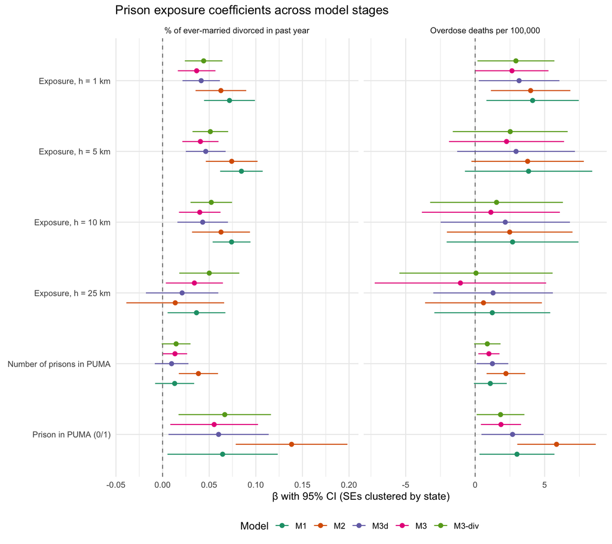

```r
results %>%
  filter(spec %in% c("M1", "M2", "M3d", "M3", "M3-div")) %>%
  ggplot(aes(x = estimate, y = fct_rev(exposure), colour = spec)) +
  geom_vline(xintercept = 0, linetype = "dashed", colour = "grey50") +
  geom_pointrange(aes(xmin = conf.low, xmax = conf.high),
                  position = position_dodge(width = 0.7), size = 0.3) +
  facet_wrap(~ outcome, scales = "free_x") +
  scale_colour_brewer(palette = "Dark2", name = "Model") +
  labs(x = "β with 95% CI (SEs clustered by state)", y = NULL,
       title = "Prison exposure coefficients across model stages") +
  theme_minimal() +
  theme(legend.position = "bottom")
```

# 5 SPATIAL DIAGNOSTICS

OLS assumes that PUMAs are independent of each other. But if neighboring pumas have similar residuals, this assumption doesn’t hold: the standard errors are wrong, and the model is missing something regional. Here we check this for M3 (all controls + state fixed effects) with all six exposure measures.

The neighbors are defined in two ways, to see if the choice matters:

Queen contiguity: PUMAs that share a border or a corner. Two PUMAs (islands) have no neighbors. 6 nearest neighbors: every PUMA gets six neighbors, no matter its size.

```r
spatial_exposures <- exposures

# Model data with boundaries, one per outcome
# Rows stay in this order for the models, the weights, and the maps.
geo_data <- map(names(outcomes),
                ~ puma_geo %>%
                    select(GEOID20) %>%
                    st_transform(5070) %>%
                    inner_join(model_data[[.x]], by = "GEOID20")) %>%
  set_names(names(outcomes))

# Queen contiguity: PUMAs that share a border or corner are neighbors
# (snap = 1 m bridges tiny gaps between cartographic boundaries)
queen_nb <- map(geo_data, ~ poly2nb(.x, queen = TRUE, snap = 1))
# 6 nearest neighbors, measured from a point inside each PUMA
knn_nb <- map(geo_data, ~ .x %>%
                            st_geometry() %>%
                            st_point_on_surface() %>%
                            st_coordinates() %>%
                            knearneigh(k = 6) %>%
                            knn2nb())
# Row-standardized weights, stored as weights[[outcome]]$queen / $knn
weights <- map2(queen_nb, knn_nb,
                ~ list(queen    = nb2listw(.x, style = "W", zero.policy = TRUE),
                       knn      = nb2listw(.y, style = "W"),
                       queen_nb = .x))
```

```r
# M3 for each outcome and exposure, refitted with lm() so the spatial tests can use it.
# The formulas come from Phase 4 (so each outcome keeps its own controls);
# only the fixed effects are written as state dummies, which lm() needs.
p5_models <- all_models %>%
  filter(spec == "M3", x %in% names(spatial_exposures)) %>%
  mutate(formula_lm = str_replace(formula, " \\| state_fips", " + factor(state_fips)"),
         model      = map2(formula_lm, y,
                           ~ lm(as.formula(.x), data = st_drop_geometry(geo_data[[.y]])))) %>%
  select(y, x, formula_lm, model)

# Sanity check: the exposure coefficients match the Phase 4 feols M3 results
p5_models %>%
  mutate(estimate_lm = map2_dbl(model, x, ~ coef(.x)[[.y]])) %>%
  left_join(results %>% filter(spec == "M3") %>% select(y, x, estimate_feols = estimate),
            by = c("y", "x")) %>%
  select(y, x, estimate_lm, estimate_feols)
```

```
# A tibble: 12 × 4
   y                       x                      estimate_lm estimate_feols
   <chr>                   <chr>                        <dbl>          <dbl>
 1 overdose_rate_2022_2024 prison_exp_h1               2.65           2.65
 2 overdose_rate_2022_2024 prison_exp_h5               2.26           2.26
 3 overdose_rate_2022_2024 prison_exp_h10              1.13           1.13
 4 overdose_rate_2022_2024 prison_exp_h25             -1.06          -1.06
 5 overdose_rate_2022_2024 num_prisons_in_puma         0.988          0.988
 6 overdose_rate_2022_2024 prison_present_in_puma      1.86           1.86
 7 pct_divorced_past_yr    prison_exp_h1               0.0365         0.0365
 8 pct_divorced_past_yr    prison_exp_h5               0.0406         0.0406
 9 pct_divorced_past_yr    prison_exp_h10              0.0399         0.0399
10 pct_divorced_past_yr    prison_exp_h25              0.0341         0.0341
11 pct_divorced_past_yr    num_prisons_in_puma         0.0133         0.0133
12 pct_divorced_past_yr    prison_present_in_puma      0.0553         0.0553
```

## 5.1 Moran’s I on the outcome and on the residuals

```r
# Clustering of the outcome itself
moran_results <- expand_grid(y = names(outcomes), w = c("queen", "knn")) %>%
  mutate(
    outcome_test = map2(y, w, ~ moran.test(geo_data[[.x]][[.x]], weights[[.x]][[.y]],
                                           zero.policy = TRUE)),
    outcome_I = map_dbl(outcome_test, ~ unname(.x$estimate[1])),
    outcome_p = map_dbl(outcome_test, ~ .x$p.value)
  ) %>%
  select(-outcome_test)

# Clustering of what the M3 model leaves unexplained
residual_moran <- p5_models %>%
  expand_grid(w = c("queen", "knn")) %>%
  mutate(
    lw         = map2(y, w, ~ weights[[.x]][[.y]]),
    test       = map2(model, lw, ~ lm.morantest(.x, .y, zero.policy = TRUE)),
    residual_I = map_dbl(test, ~ unname(.x$estimate[1])),
    residual_p = map_dbl(test, ~ .x$p.value)
  ) %>%
  select(y, x, w, residual_I, residual_p)

residual_moran %>%
  left_join(moran_results, by = c("y", "w")) %>%
  mutate(outcome  = outcomes[y],
         exposure = spatial_exposures[x],
         weights  = if_else(w == "queen", "Queen contiguity", "6 nearest neighbors")) %>%
  select(outcome, weights, exposure, outcome_I, residual_I, residual_p) %>%
  arrange(outcome, weights) %>%
  gt(groupname_col = c("outcome", "weights")) %>%
  fmt_number(columns = c(outcome_I, residual_I), decimals = 3) %>%
  fmt_number(columns = residual_p, decimals = 4) %>%
  cols_label(exposure = "Model (M3) with", outcome_I = "Moran's I: outcome",
             residual_I = "Moran's I: M3 residuals", residual_p = "p (residuals)") %>%
  tab_header(title = "Spatial clustering before and after the model")
```

Spatial clustering before and after the model

| Model (M3) with | Moran's I: outcome | Moran's I: M3 residuals | p (residuals) |
| --- | --- | --- | --- |
| % of ever-married divorced in past year - 6 nearest neighbors |  |  |  |
| Exposure, h = 1 km | 0.154 | 0.042 | 0.0000 |
| Exposure, h = 5 km | 0.154 | 0.044 | 0.0000 |
| Exposure, h = 10 km | 0.154 | 0.045 | 0.0000 |
| Exposure, h = 25 km | 0.154 | 0.045 | 0.0000 |
| Number of prisons in PUMA | 0.154 | 0.046 | 0.0000 |
| Prison in PUMA (0/1) | 0.154 | 0.044 | 0.0000 |
| % of ever-married divorced in past year - Queen contiguity |  |  |  |
| Exposure, h = 1 km | 0.155 | 0.039 | 0.0000 |
| Exposure, h = 5 km | 0.155 | 0.039 | 0.0000 |
| Exposure, h = 10 km | 0.155 | 0.040 | 0.0000 |
| Exposure, h = 25 km | 0.155 | 0.041 | 0.0000 |
| Number of prisons in PUMA | 0.155 | 0.042 | 0.0000 |
| Prison in PUMA (0/1) | 0.155 | 0.040 | 0.0000 |
| Overdose deaths per 100,000 - 6 nearest neighbors |  |  |  |
| Exposure, h = 1 km | 0.562 | 0.510 | 0.0000 |
| Exposure, h = 5 km | 0.562 | 0.511 | 0.0000 |
| Exposure, h = 10 km | 0.562 | 0.507 | 0.0000 |
| Exposure, h = 25 km | 0.562 | 0.504 | 0.0000 |
| Number of prisons in PUMA | 0.562 | 0.504 | 0.0000 |
| Prison in PUMA (0/1) | 0.562 | 0.506 | 0.0000 |
| Overdose deaths per 100,000 - Queen contiguity |  |  |  |
| Exposure, h = 1 km | 0.582 | 0.522 | 0.0000 |
| Exposure, h = 5 km | 0.582 | 0.523 | 0.0000 |
| Exposure, h = 10 km | 0.582 | 0.519 | 0.0000 |
| Exposure, h = 25 km | 0.582 | 0.515 | 0.0000 |
| Number of prisons in PUMA | 0.582 | 0.516 | 0.0000 |
| Prison in PUMA (0/1) | 0.582 | 0.517 | 0.0000 |

Based on Moran’s I, overdose rates are strongly clustered, both for the outcome itself and for the residuals. This clustering might be real, but given the way the puma overdose rates were produced, it may partly be an artifact of the data. This is also supported by Moran’s I for suicide rates, which also come from the CDC and show even stronger clustering. This suggests that the way the data are constructed may produce artificial clustering.

## 5.2 Residual maps

Where M3 over- and under-predicts:

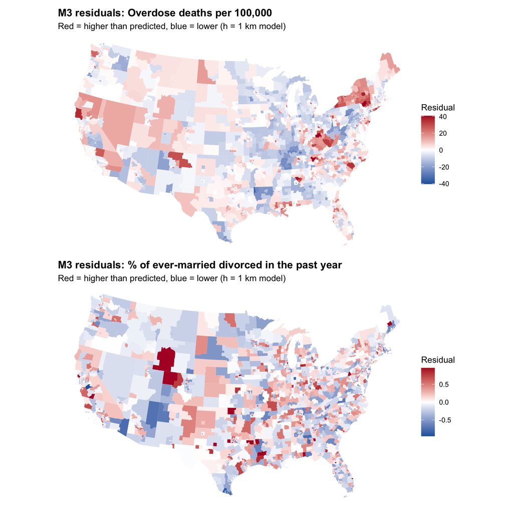

```r
# The M3 model (h = 1 km) for each outcome
m_od  <- p5_models %>% filter(y == "overdose_rate_2022_2024", x == "prison_exp_h1") %>% pull(model) %>% first()
m_div <- p5_models %>% filter(y == "pct_divorced_past_yr",    x == "prison_exp_h1") %>% pull(model) %>% first()

# Overdose: residual for each PUMA, capped at the 98th percentile so a few extreme PUMAs
# don't wash out the colours
resid_map_od <- geo_data$overdose_rate_2022_2024 %>%
  mutate(resid = residuals(m_od),
         lim   = quantile(abs(resid), 0.98),
         resid_capped = case_when(resid >  lim ~  lim,
                                  resid < -lim ~ -lim,
                                  TRUE         ~ resid)) %>%
  filter(!state_fips %in% c("02", "15")) %>%            # lower 48 only
  ggplot() +
  geom_sf(aes(fill = resid_capped), colour = NA) +
  scale_fill_gradient2(low = "#2166ac", mid = "white", high = "#b2182b",
                       midpoint = 0, name = "Residual") +
  labs(title = "M3 residuals: Overdose deaths per 100,000",
       subtitle = "Red = higher than predicted, blue = lower (h = 1 km model)") +
  theme_void() +
  theme(plot.title = element_text(face = "bold"))

# Divorce: same steps
resid_map_div <- geo_data$pct_divorced_past_yr %>%
  mutate(resid = residuals(m_div),
         lim   = quantile(abs(resid), 0.98),
         resid_capped = case_when(resid >  lim ~  lim,
                                  resid < -lim ~ -lim,
                                  TRUE         ~ resid)) %>%
  filter(!state_fips %in% c("02", "15")) %>%
  ggplot() +
  geom_sf(aes(fill = resid_capped), colour = NA) +
  scale_fill_gradient2(low = "#2166ac", mid = "white", high = "#b2182b",
                       midpoint = 0, name = "Residual") +
  labs(title = "M3 residuals: % of ever-married divorced in the past year",
       subtitle = "Red = higher than predicted, blue = lower (h = 1 km model)") +
  theme_void() +
  theme(plot.title = element_text(face = "bold"))

resid_map_od / resid_map_div
```

# 6 SPATIAL MODELS

| Model | Assumes | Role here |
| --- | --- | --- |
| SEM | nearby PUMAs share unmeasured conditions, so their errors are correlated | main spatial model |
| SDEM | SEM + exposure in neighboring PUMAs can matter too | do prisons just outside a PUMA matter? |

Both keep the full M3 specification (each outcome with its own controls). They’re estimated by maximum likelihood, so the standard errors are model-based, not clustered.

## 6.1 Setup

The spatial models need neighbor relations to go both ways, so the kNN weights were made symmetric: two pumas are neighbors if either one is among the other’s 6 nearest. Because of this, some PUMAs end up with a few more than six neighbors.

```r
weight_labels <- c(queen = "Queen", knn = "kNN (k = 6)")

# Weights for the spatial models. kNN is made symmetric (neighbors if either PUMA is among
# the other's 6 nearest), which the exact eigenvalue method requires. Queen is already symmetric.
p6_weights <- map(weights, ~ list(queen = .x$queen,
                                  knn   = nb2listw(make.sym.nb(.x$knn$neighbours), style = "W")))

# Eigenvalues of each weights matrix, computed once and reused by every model.
# similar.listw() gives an equivalent symmetric matrix, so the eigenvalues are real.
p6_eig <- map(p6_weights, ~ list(queen = eigenw(similar.listw(.x$queen)),
                                 knn   = eigenw(similar.listw(.x$knn))))
```

## 6.2 SEM and SDEM, all exposure measures

```r
# Slow (2 outcomes x 6 exposures x 2 weight matrices x 2 models), so this is run by hand
# once and the fitted models are saved; the next chunk reads them.
# Formulas: the M3 formulas from Phase 5 (each outcome keeps its own controls).
# "eigen" computes exact standard errors from the precomputed eigenvalues.
#p5_models %>%
#  select(y, x, formula_lm) %>%
#  expand_grid(w = names(weight_labels)) %>%
#  mutate(
#    sem  = pmap(list(formula_lm, y, w),
#                ~ errorsarlm(as.formula(..1), data = st_drop_geometry(geo_data[[..2]]),
#                             listw = p6_weights[[..2]][[..3]], method = "eigen",
#                             control = list(pre_eig = p6_eig[[..2]][[..3]]),
#                             zero.policy = TRUE),
#                .progress = "SEM"),
#    sdem = pmap(list(formula_lm, y, w, x),
#                ~ errorsarlm(as.formula(..1), data = st_drop_geometry(geo_data[[..2]]),
#                             listw = p6_weights[[..2]][[..3]],
#                             Durbin = as.formula(paste("~", ..4)),   # lag only the exposure
#                             method = "eigen",
#                             control = list(pre_eig = p6_eig[[..2]][[..3]]),
#                             zero.policy = TRUE),
#                .progress = "SDEM")
#  ) %>%
#  saveRDS("data/final/p6_error_models.rds")
```

```r
error_models <- readRDS("data/final/p6_error_models.rds")
```

```r
error_results <- error_models %>%
  mutate(
    # SEM: the exposure coefficient
    sem_coef = map2(sem, x, ~ as_tibble(summary(.x)$Coef, rownames = "term") %>%
                               filter(term == .y) %>%
                               transmute(estimate = Estimate, std.error = `Std. Error`,
                                         p.value = `Pr(>|z|)`)),
    sem_lambda = map_dbl(sem, ~ .x$lambda),
    sem_aic    = map_dbl(sem, AIC),

    # SDEM direct: exposure in the PUMA itself
    sdem_direct = map2(sdem, x, ~ as_tibble(summary(.x)$Coef, rownames = "term") %>%
                                   filter(term == .y) %>%
                                   transmute(estimate = Estimate, std.error = `Std. Error`,
                                             p.value = `Pr(>|z|)`)),
    # SDEM indirect: exposure in neighboring PUMAs (the "lag." term)
    sdem_indirect = map2(sdem, x, ~ as_tibble(summary(.x)$Coef, rownames = "term") %>%
                                     filter(term == paste0("lag.", .y)) %>%
                                     transmute(estimate = Estimate, std.error = `Std. Error`,
                                               p.value = `Pr(>|z|)`)),
    # SDEM total = direct + indirect; its SE uses the covariance between the two
    sdem_total = map2(sdem, x, ~ tibble(
                   estimate  = sum(coef(.x)[c(.y, paste0("lag.", .y))]),
                   std.error = sqrt(sum(vcov(.x)[c(.y, paste0("lag.", .y)),
                                                 c(.y, paste0("lag.", .y))]))) %>%
                   mutate(p.value = 2 * pnorm(-abs(estimate / std.error)))),
    sdem_lambda = map_dbl(sdem, ~ .x$lambda),
    sdem_aic    = map_dbl(sdem, AIC)
  ) %>%
  select(-sem, -sdem)

# OLS M3 (state-clustered) from Phase 4, for comparison
ols_m3 <- results %>%
  filter(spec == "M3") %>%
  select(y, x, ols_estimate = estimate, ols_se = std.error, ols_p = p.value)
```

## 6.3 One exposure in detail: OLS vs. SEM vs. SDEM

Set `main_x` at the top of the chunk to choose the exposure. It’s also used by the model checks below.

```r
# One comparison table: OLS M3 vs. SEM vs. SDEM for the main exposure,
# for each outcome and weights matrix

#specify the variable you want to look at
#options: prison_exp_h1, prison_exp_h5, prison_exp_h10, prison_exp_h25, num_prisons_in_puma, prison_present_in_puma

main_x <- "prison_exp_h1"

main_table <- bind_rows(
  # OLS M3 doesn't use the weights, so the same row is repeated for both weights matrices
  ols_m3 %>%
    filter(x == main_x) %>%
    expand_grid(w = names(weight_labels)) %>%
    transmute(y, w, model = "OLS M3 (state-clustered SEs)", effect = "Coefficient",
              estimate = ols_estimate, std.error = ols_se, p.value = ols_p,
              spatial_param = NA_real_, aic = NA_real_),

  # SEM: exposure coefficient, with lambda and AIC
  error_results %>%
    filter(x == main_x) %>%
    select(y, w, sem_coef, sem_lambda, sem_aic) %>%
    unnest(sem_coef) %>%
    transmute(y, w, model = "SEM", effect = "Coefficient",
              estimate, std.error, p.value,
              spatial_param = sem_lambda, aic = sem_aic),

  # SDEM direct: exposure in the PUMA itself (lambda and AIC shown on this row)
  error_results %>%
    filter(x == main_x) %>%
    select(y, w, sdem_direct, sdem_lambda, sdem_aic) %>%
    unnest(sdem_direct) %>%
    transmute(y, w, model = "SDEM", effect = "Direct",
              estimate, std.error, p.value,
              spatial_param = sdem_lambda, aic = sdem_aic),

  # SDEM indirect: exposure in neighboring PUMAs
  error_results %>%
    filter(x == main_x) %>%
    select(y, w, sdem_indirect) %>%
    unnest(sdem_indirect) %>%
    transmute(y, w, model = "SDEM", effect = "Indirect (neighbors)",
              estimate, std.error, p.value,
              spatial_param = NA_real_, aic = NA_real_),

  # SDEM total: direct + indirect
  error_results %>%
    filter(x == main_x) %>%
    select(y, w, sdem_total) %>%
    unnest(sdem_total) %>%
    transmute(y, w, model = "SDEM", effect = "Total",
              estimate, std.error, p.value,
              spatial_param = NA_real_, aic = NA_real_)
) %>%
  mutate(outcome = outcomes[y],
         weights = weight_labels[w],
         model   = factor(model, levels = c("OLS M3 (state-clustered SEs)", "SEM", "SDEM")),
         effect  = factor(effect, levels = c("Coefficient", "Direct",
                                             "Indirect (neighbors)", "Total"))) %>%
  arrange(outcome, weights, model, effect)

main_table %>%
  select(outcome, weights, model, effect, estimate, std.error, p.value, spatial_param, aic) %>%
  gt(groupname_col = c("outcome", "weights")) %>%
  fmt_number(columns = c(estimate, std.error, spatial_param), decimals = 3) %>%
  fmt_number(columns = p.value, decimals = 4) %>%
  fmt_number(columns = aic, decimals = 1) %>%
  sub_missing(missing_text = "") %>%
  cols_label(model = "Model", effect = "Effect", estimate = "β", std.error = "SE",
             p.value = "p", spatial_param = "λ", aic = "AIC") %>%
  tab_style(style = cell_fill(color = "#fff3cd"), locations = cells_body(rows = p.value < 0.05)) %>%
  tab_header(title = paste0("Main exposure (", exposures[[main_x]], ", per SD): OLS vs. spatial error models"),
             subtitle = "λ = spatial error parameter (how strongly neighboring PUMAs share unexplained variation). Shaded: p < 0.05")
```

Main exposure (Exposure, h = 1 km, per SD): OLS vs. spatial error models

λ = spatial error parameter (how strongly neighboring PUMAs share unexplained variation). Shaded: p < 0.05

| Model | Effect | β | SE | p | λ | AIC |
| --- | --- | --- | --- | --- | --- | --- |
| % of ever-married divorced in past year - Queen |  |  |  |  |  |  |
| OLS M3 (state-clustered SEs) | Coefficient | 0.037 | 0.010 | 0.0007 |  |  |
| SEM | Coefficient | 0.035 | 0.008 | 0.0000 | 0.101 | 2,204.7 |
| SDEM | Direct | 0.034 | 0.009 | 0.0001 | 0.100 | 2,206.3 |
| SDEM | Indirect (neighbors) | 0.011 | 0.016 | 0.5014 |  |  |
| SDEM | Total | 0.044 | 0.015 | 0.0038 |  |  |
| % of ever-married divorced in past year - kNN (k = 6) |  |  |  |  |  |  |
| OLS M3 (state-clustered SEs) | Coefficient | 0.037 | 0.010 | 0.0007 |  |  |
| SEM | Coefficient | 0.035 | 0.008 | 0.0000 | 0.147 | 2,199.4 |
| SDEM | Direct | 0.033 | 0.008 | 0.0001 | 0.149 | 2,199.4 |
| SDEM | Indirect (neighbors) | 0.026 | 0.018 | 0.1502 |  |  |
| SDEM | Total | 0.059 | 0.019 | 0.0016 |  |  |
| Overdose deaths per 100,000 - Queen |  |  |  |  |  |  |
| OLS M3 (state-clustered SEs) | Coefficient | 2.648 | 1.308 | 0.0483 |  |  |
| SEM | Coefficient | 2.304 | 0.221 | 0.0000 | 0.804 | 18,519.3 |
| SDEM | Direct | 2.654 | 0.235 | 0.0000 | 0.809 | 18,503.9 |
| SDEM | Indirect (neighbors) | 2.523 | 0.601 | 0.0000 |  |  |
| SDEM | Total | 5.177 | 0.720 | 0.0000 |  |  |
| Overdose deaths per 100,000 - kNN (k = 6) |  |  |  |  |  |  |
| OLS M3 (state-clustered SEs) | Coefficient | 2.648 | 1.308 | 0.0483 |  |  |
| SEM | Coefficient | 2.638 | 0.224 | 0.0000 | 0.789 | 18,770.8 |
| SDEM | Direct | 2.887 | 0.243 | 0.0000 | 0.794 | 18,766.3 |
| SDEM | Indirect (neighbors) | 1.896 | 0.742 | 0.0106 |  |  |
| SDEM | Total | 4.783 | 0.868 | 0.0000 |  |  |

## 6.4 All exposure measures: OLS vs. SEM vs. SDEM

```r
error_results %>%
  mutate(sem = sem_coef, direct = sdem_direct, indirect = sdem_indirect) %>%
  select(y, x, w, sem, direct, indirect, sem_lambda) %>%
  unnest_wider(sem,      names_sep = "_") %>%
  unnest_wider(direct,   names_sep = "_") %>%
  unnest_wider(indirect, names_sep = "_") %>%
  left_join(ols_m3, by = c("y", "x")) %>%
  mutate(outcome  = outcomes[y],
         exposure = factor(exposures[x], levels = exposures),
         weights  = weight_labels[w]) %>%
  arrange(outcome, weights, exposure) %>%
  select(outcome, weights, exposure,
         ols_estimate, ols_p,
         sem_estimate, sem_p.value,
         direct_estimate, direct_p.value,
         indirect_estimate, indirect_p.value,
         sem_lambda) %>%
  gt(groupname_col = c("outcome", "weights")) %>%
  fmt_number(columns = c(ols_estimate, sem_estimate, direct_estimate, indirect_estimate, sem_lambda),
             decimals = 3) %>%
  fmt_number(columns = c(ols_p, sem_p.value, direct_p.value, indirect_p.value), decimals = 4) %>%
  cols_label(exposure = "Exposure", ols_estimate = "OLS β", ols_p = "p",
             sem_estimate = "SEM β", sem_p.value = "p",
             direct_estimate = "SDEM direct", direct_p.value = "p",
             indirect_estimate = "SDEM indirect", indirect_p.value = "p",
             sem_lambda = "SEM λ") %>%
  tab_spanner(label = "OLS M3", columns = c(ols_estimate, ols_p)) %>%
  tab_spanner(label = "SEM", columns = c(sem_estimate, sem_p.value, sem_lambda)) %>%
  tab_spanner(label = "SDEM", columns = c(direct_estimate, direct_p.value,
                                          indirect_estimate, indirect_p.value)) %>%
  tab_header(title = "Exposure coefficients: OLS M3 vs. spatial error models",
             subtitle = "Continuous exposures per SD; presence = with vs. without")
```

Exposure coefficients: OLS M3 vs. spatial error models

Continuous exposures per SD; presence = with vs. without

| Exposure | OLS M3 OLS β | OLS M3 p | SEM SEM β | SEM p | SEM SEM λ | SDEM SDEM direct | SDEM p | SDEM SDEM indirect | SDEM p |
| --- | --- | --- | --- | --- | --- | --- | --- | --- | --- |
| % of ever-married divorced in past year - Queen |  |  |  |  |  |  |  |  |  |
| Exposure, h = 1 km | 0.037 | 0.0007 | 0.035 | 0.0000 | 0.101 | 0.034 | 0.0001 | 0.011 | 0.5014 |
| Exposure, h = 5 km | 0.041 | 0.0001 | 0.041 | 0.0000 | 0.101 | 0.054 | 0.0001 | −0.026 | 0.1944 |
| Exposure, h = 10 km | 0.040 | 0.0007 | 0.040 | 0.0002 | 0.103 | 0.077 | 0.0001 | −0.056 | 0.0239 |
| Exposure, h = 25 km | 0.034 | 0.0297 | 0.034 | 0.0148 | 0.106 | 0.117 | 0.0006 | −0.105 | 0.0074 |
| Number of prisons in PUMA | 0.013 | 0.0459 | 0.011 | 0.2006 | 0.107 | 0.013 | 0.1340 | 0.048 | 0.0012 |
| Prison in PUMA (0/1) | 0.055 | 0.0221 | 0.050 | 0.0068 | 0.103 | 0.054 | 0.0036 | 0.113 | 0.0015 |
| % of ever-married divorced in past year - kNN (k = 6) |  |  |  |  |  |  |  |  |  |
| Exposure, h = 1 km | 0.037 | 0.0007 | 0.035 | 0.0000 | 0.147 | 0.033 | 0.0001 | 0.026 | 0.1502 |
| Exposure, h = 5 km | 0.041 | 0.0001 | 0.041 | 0.0000 | 0.150 | 0.046 | 0.0001 | −0.014 | 0.4099 |
| Exposure, h = 10 km | 0.040 | 0.0007 | 0.041 | 0.0002 | 0.153 | 0.062 | 0.0000 | −0.040 | 0.0497 |
| Exposure, h = 25 km | 0.034 | 0.0297 | 0.036 | 0.0135 | 0.155 | 0.088 | 0.0007 | −0.073 | 0.0154 |
| Number of prisons in PUMA | 0.013 | 0.0459 | 0.012 | 0.1562 | 0.156 | 0.013 | 0.1477 | 0.019 | 0.3620 |
| Prison in PUMA (0/1) | 0.055 | 0.0221 | 0.051 | 0.0059 | 0.152 | 0.053 | 0.0040 | 0.089 | 0.0508 |
| Overdose deaths per 100,000 - Queen |  |  |  |  |  |  |  |  |  |
| Exposure, h = 1 km | 2.648 | 0.0483 | 2.304 | 0.0000 | 0.804 | 2.654 | 0.0000 | 2.523 | 0.0000 |
| Exposure, h = 5 km | 2.257 | 0.2787 | 3.294 | 0.0000 | 0.808 | 3.236 | 0.0000 | 0.791 | 0.2905 |
| Exposure, h = 10 km | 1.130 | 0.6494 | 2.877 | 0.0000 | 0.808 | 2.922 | 0.0000 | −0.231 | 0.7932 |
| Exposure, h = 25 km | −1.062 | 0.7309 | 1.377 | 0.0530 | 0.805 | 2.306 | 0.0077 | −2.347 | 0.0554 |
| Number of prisons in PUMA | 0.988 | 0.0122 | 0.485 | 0.0205 | 0.802 | 0.628 | 0.0168 | 0.492 | 0.3681 |
| Prison in PUMA (0/1) | 1.857 | 0.0128 | 1.261 | 0.0049 | 0.802 | 1.790 | 0.0013 | 2.102 | 0.1056 |
| Overdose deaths per 100,000 - kNN (k = 6) |  |  |  |  |  |  |  |  |  |
| Exposure, h = 1 km | 2.648 | 0.0483 | 2.638 | 0.0000 | 0.789 | 2.887 | 0.0000 | 1.896 | 0.0106 |
| Exposure, h = 5 km | 2.257 | 0.2787 | 3.537 | 0.0000 | 0.794 | 3.529 | 0.0000 | −0.217 | 0.7753 |
| Exposure, h = 10 km | 1.130 | 0.6494 | 3.197 | 0.0000 | 0.793 | 3.285 | 0.0000 | −1.442 | 0.0918 |
| Exposure, h = 25 km | −1.062 | 0.7309 | 1.560 | 0.0173 | 0.786 | 2.116 | 0.0034 | −2.189 | 0.0552 |
| Number of prisons in PUMA | 0.988 | 0.0122 | 0.744 | 0.0018 | 0.782 | 0.710 | 0.0088 | −0.224 | 0.7896 |
| Prison in PUMA (0/1) | 1.857 | 0.0128 | 1.953 | 0.0001 | 0.783 | 1.706 | 0.0028 | −1.697 | 0.3622 |

## 6.5 Model checks

Three checks for the exposure chosen in `main_x`: a Hausman test (do OLS and SEM coefficients differ more than chance allows?), Moran’s I on the SEM and SDEM residuals (should be close to zero), and AIC for OLS M3, SEM and SDEM (lower is better).

```r
# Hausman test: do OLS and SEM coefficients differ more than chance allows?
hausman_safe <- possibly(Hausman.test, otherwise = list(statistic = NA_real_, p.value = NA_real_))

hausman <- error_models %>%
  filter(x == main_x) %>%
  mutate(test      = map(sem, hausman_safe),
         statistic = map_dbl(test, ~ unname(.x$statistic)),
         p.value   = map_dbl(test, ~ .x$p.value)) %>%
  transmute(outcome = outcomes[y], weights = weight_labels[w], statistic, p.value)
hausman
```

```
# A tibble: 4 × 4
  outcome                                 weights     statistic p.value
  <chr>                                   <chr>           <dbl>   <dbl>
1 Overdose deaths per 100,000             Queen           -16.2 1.00
2 Overdose deaths per 100,000             kNN (k = 6)     943.  0
3 % of ever-married divorced in past year Queen            77.0 0.0690
4 % of ever-married divorced in past year kNN (k = 6)      91.2 0.00583
```

```r
# Is spatial structure left in the residuals of SEM and SDEM? (should be close to zero)
resid_moran <- error_models %>%
  filter(x == main_x) %>%
  pivot_longer(c(sem, sdem), names_to = "model", values_to = "fit") %>%
  mutate(
    lw = map2(y, w, ~ p6_weights[[.x]][[.y]]),
    e  = map(fit, ~ as.vector(.x$y - .x$X %*% .x$coefficients)),
    u  = pmap(list(e, fit, lw), ~ ..1 - ..2$lambda * lag.listw(..3, ..1, zero.policy = TRUE)),
    moran_I = map2_dbl(u, lw, ~ unname(moran.test(.x, .y, zero.policy = TRUE)$estimate[1])),
    moran_p = map2_dbl(u, lw, ~ moran.test(.x, .y, zero.policy = TRUE)$p.value)
  ) %>%
  transmute(outcome = outcomes[y], weights = weight_labels[w],
            model = toupper(model), moran_I, moran_p)
resid_moran
```

```
# A tibble: 8 × 5
  outcome                                 weights     model  moran_I moran_p
  <chr>                                   <chr>       <chr>    <dbl>   <dbl>
1 Overdose deaths per 100,000             Queen       SEM   -0.0306    0.991
2 Overdose deaths per 100,000             Queen       SDEM  -0.0328    0.994
3 Overdose deaths per 100,000             kNN (k = 6) SEM   -0.0218    0.982
4 Overdose deaths per 100,000             kNN (k = 6) SDEM  -0.0234    0.988
5 % of ever-married divorced in past year Queen       SEM   -0.00129   0.528
6 % of ever-married divorced in past year Queen       SDEM  -0.00128   0.527
7 % of ever-married divorced in past year kNN (k = 6) SEM   -0.00134   0.536
8 % of ever-married divorced in past year kNN (k = 6) SDEM  -0.00138   0.538
```

```r
# Fit across models for the main measure (lower AIC = better).

error_results %>%
  filter(x == main_x) %>%
  select(y, w, sem_aic, sdem_aic) %>%
  left_join(p5_models %>%
              filter(x == main_x) %>%
              transmute(y, ols_aic = map_dbl(model, AIC)),
            by = "y") %>%
  mutate(outcome = outcomes[y], weights = weight_labels[w]) %>%
  select(outcome, weights, `OLS M3` = ols_aic, SEM = sem_aic, SDEM = sdem_aic)
```

```
# A tibble: 4 × 5
  outcome                                 weights     `OLS M3`    SEM   SDEM
  <chr>                                   <chr>          <dbl>  <dbl>  <dbl>
1 Overdose deaths per 100,000             Queen         20018. 18519. 18504.
2 Overdose deaths per 100,000             kNN (k = 6)   20018. 18771. 18766.
3 % of ever-married divorced in past year Queen          2212.  2205.  2206.
4 % of ever-married divorced in past year kNN (k = 6)    2212.  2199.  2199.
```